# TCC Ciência de Dados - Jurimetria e Séries Temporais

# 4. Avaliações de correlação e sincronia

## Testes - Pearson

Estou largando o pearson pela argumentação: https://stats.stackexchange.com/questions/133155/how-to-use-pearson-correlation-correctly-with-time-series

```r
# result_ts_stl_cymt_top5_tipo contem as séries por tipo com a decomposição

# Teste com duas séries quaisquer, pelo componente trend
# pearson <- cor.test(list_stl_ts_cymt_top5_tipo[[3]]$time.series[,1], list_stl_ts_cymt_top5_tipo[[5]]$time.series[,1], method="pearson" )
# plot(pearson)

# ggscatter([result_ts_stl_cymt_top5_tipo[[3]]$time.series[,1], result_ts_stl_cymt_top5_tipo[[5]]$time.series[,1]],
#           add = "reg.line", conf.int = TRUE,
#           cor.coef = TRUE, cor.method = "pearson",
#           xlab = "tipo 3", ylab = "tipo 5")

# list_pearson <- list()
#
# list_tlcc <- list()
#
# position <- 1
# for (tipo_top5_ts in list_stl_ts_cymt_top5_tipo) {
#   # Cria uma cópia da lista de séries removendo a série em questão para comparar com as demais
#   resto_list <- duplicate(list_stl_ts_cymt_top5_tipo, shallow = FALSE)
#   resto_list[position]<-NULL
#
#   for(compara in resto_list){
#     # print(length(tipo_top5_ts$time.series[,1]))
#     # print(length(compara$time.series[,1]))
#     #list_pearson<-c(list_pearson, cor.test(tipo_top5_ts$time.series[,1], compara$time.series[,1], method="pearson" ))
#     corobject<-ccf(tipo_top5_ts$time.series[,2],compara$time.series[,2],type="correlation",plot=FALSE)
#     corobject$series<-"Trend Mês-Ano"
#     corobject$snames<-paste(tipo_top5_ts$nome,"x",compara$nome)
#     list_pearson<- list.append(list_pearson,corobject)
#     ggplotly(ggplot(x = corobject$acf, y = corobject$lag ))
#     # fig <- plot_ly(x = corobject$acf, y = corobject$lag )
#     # fig
#   }
#   position <- position+1
# }
```

## Testes - Time Lagged Cross Correlation

### * Verificar com o professor como eu poderia descrever

### Avaliação da Janela de Mês-Ano no período todo usando correlação cruzada

#### Cada top5 avaliado com os outros.

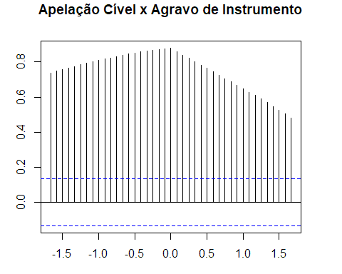

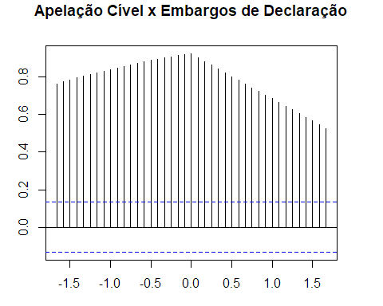

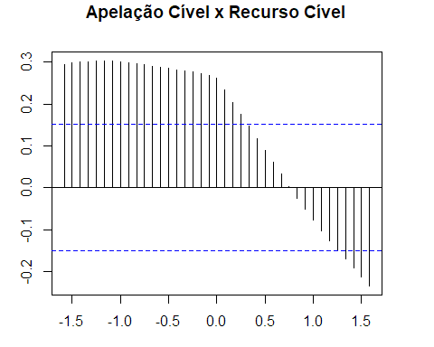

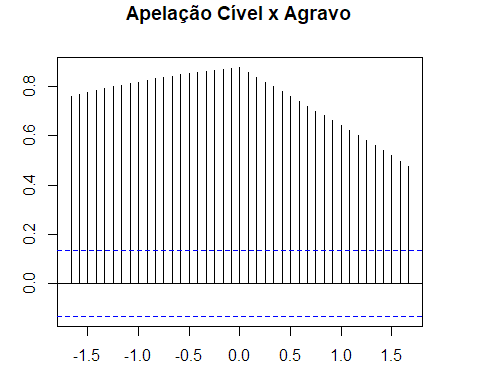

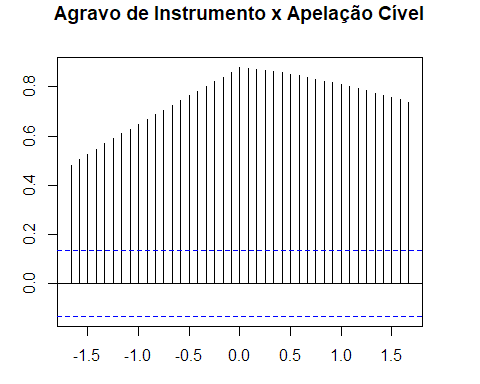

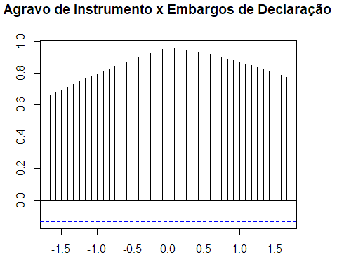

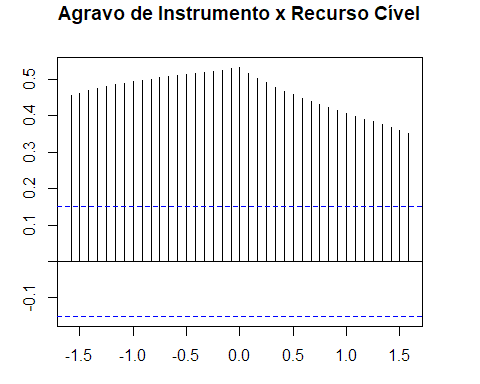

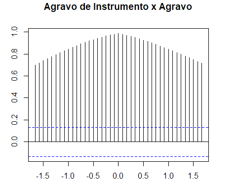

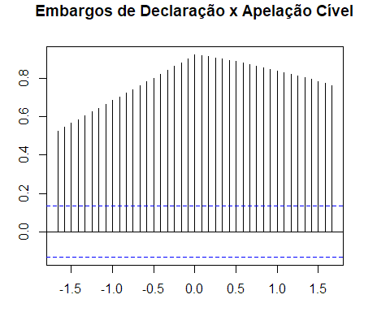

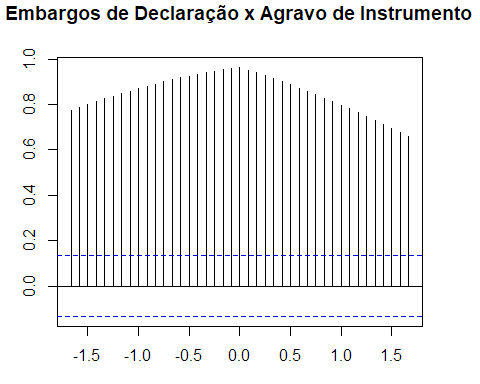

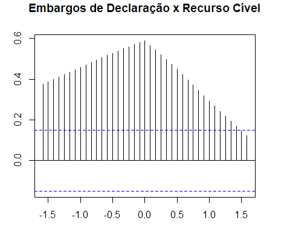

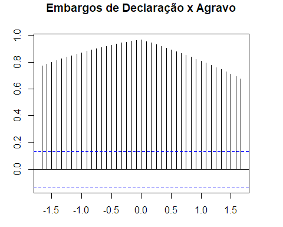

[8 more figures not shown]

```r
list_tlcc <- list()

position <- 1
for (tipo_top5_ts in list_stl_ts_cymt_top5_tipo) {
  # Cria uma cópia da lista de séries removendo a série em questão para comparar com as demais
  resto_list <- duplicate(list_stl_ts_cymt_top5_tipo, shallow = FALSE)
  resto_list[position]<-NULL

  for(compara in resto_list){
    # print(length(tipo_top5_ts$time.series[,1]))
    # print(length(compara$time.series[,1]))
    #list_pearson<-c(list_pearson, cor.test(tipo_top5_ts$time.series[,1], compara$time.series[,1], method="pearson" ))
    corobject<-ccf(tipo_top5_ts$time.series[,2],compara$time.series[,2],type="correlation",plot=FALSE)
    corobject$series<-"Trend Mês-Ano"
    corobject$snames<-paste(tipo_top5_ts$nome,"x",compara$nome)
    list_tlcc<- list.append(list_tlcc,corobject)

    par(mar=c(3,3,3,3)) #Correção de margens para não ocultar partes do gráfico
    plot(corobject)
    # ggplotly(ggplot(x = corobject$acf, y = corobject$lag ))
    # fig <- plot_ly(x = corobject$acf, y = corobject$lag )
    # fig
  }
  position <- position+1
}
```

```r
# ccf(result_ts_stl_cymt_top5_tipo[[3]]$time.series[,1],result_ts_stl_cymt_top5_tipo[[5]]$time.series[,1],type="correlation")
```

# Implementação de VAR

## Preparação das séries temporais CYMT (Count Year Month Type) e CDT (Count Day Type) para o VAR

### Preparo CYMT (Count Year Month Type)

Avaliação do VAR na série de Ano Mês

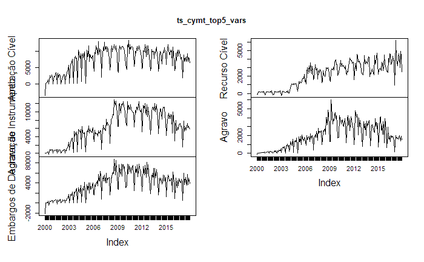

```r
#Preparo da série contendo todos os tipos

list_cymt_top5 <- foreach(tipo=top5$type) %do% {
  filtro_tipo <- cymt_top5 %>% filter(type==tipo)

  #Tratamento para série temporal
  ts_filtro_tipo<- ts_ts( xts(order.by = filtro_tipo$yearMonth,filtro_tipo$count))
}


ts_cymt_top5_vars<- list_cymt_top5[[1]] %>% merge.zoo(list_cymt_top5[[2]])
for (i in 3:5) {
  ts_cymt_top5_vars<- ts_cymt_top5_vars %>% merge.zoo(list_cymt_top5[[i]])
}




# Imputando NAs através de pesos de interpolação
ts_cymt_top5_vars<- ts_cymt_top5_vars %>% na_seadec(algorithm = "interpolation")
colnames(ts_cymt_top5_vars) = top5$type
plot(ts_cymt_top5_vars,ask=F)
```

```r
# Dividindo a amostra em treino e teste para validar predições
# O teste será a proporção ao final, para validar predição de pontos futuros na série (a seleção aleatória não funcionaria)
# A divisão de treino e teste será pela data limite de Dez/2015 - em torno de 88,88% dos dados (16 anos)
# Teste conterá os dados a partir de Jan/2016 (2 anos) A ser utilizado para comparar com os resultados de Forecast

# 216 observações de 5 variáveis
ts_cymt_top5_vars_train<-ts_cymt_top5_vars[0:192,]
ts_cymt_top5_vars_test<-ts_cymt_top5_vars[193:216,]

tail(ts_cymt_top5_vars_train)
```

```
         Apelação Cível Agravo de Instrumento Embargos de Declaração Recurso Cível Agravo
jul 2015          10451                  8462                   4441          3401   2131
ago 2015           9842                  9489                   4821          2625   3552
set 2015          10415                  9060                   4911          3047   3020
out 2015           5592                  4865                   2198          4514   1152
nov 2015          11321                 10047                   6142          3407   3935
dez 2015           6808                  6941                   4232          2943   2692
```

```r
head(ts_cymt_top5_vars_test)
```

```
         Apelação Cível Agravo de Instrumento Embargos de Declaração Recurso Cível Agravo
jan 2016           4095                  2923                    908          2568    598
fev 2016           5049                  6520                   3220          2567   1424
mar 2016           9418                  8000                   5007          2428   2923
abr 2016           7118                  5400                   3667          4041   1698
mai 2016           9192                  5595                   3029          3664   1532
jun 2016          10406                  6141                   4540          4654   1944
```

### Preparo CDT (Count Day Type)

Avaliação do VAR na série por dia

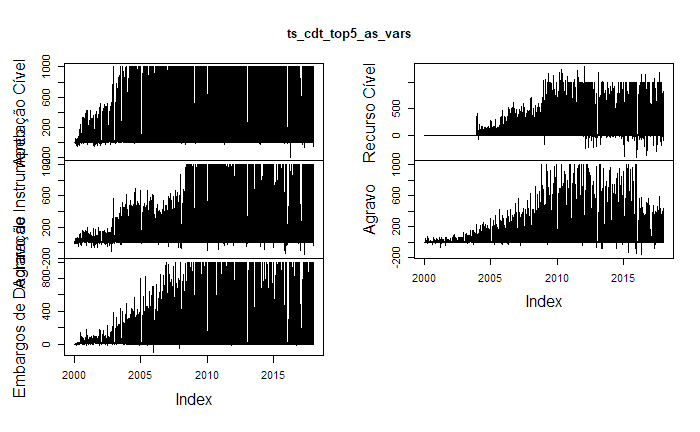

```r
list_cdt_top5 <- foreach(tipo=top5$type) %do% {
  filtro_tipo <- cdt_top5 %>% filter(type==tipo)

  #Tratamento de série para limpar NAs
  ts_filtro_tipo<- ts_ts( xts(order.by = filtro_tipo$judgmentDate,filtro_tipo$count))
  # Imputando NAs através de pesos de interpolação
  ts_filtro_tipo <- ts_filtro_tipo %>% na_seadec(algorithm = "interpolation")


}


ts_cdt_top5_as_vars<- list_cdt_top5[[1]] %>% merge.zoo(list_cdt_top5[[2]],all= TRUE,fill=0)
for (i in 3:5) {
  ts_cdt_top5_as_vars<- ts_cdt_top5_as_vars %>% merge.zoo(list_cdt_top5[[i]],all= TRUE,fill=0)
}

# Imputando NAs através de pesos de interpolação
ts_cdt_top5_as_vars<- ts_cdt_top5_as_vars %>% na_seadec(algorithm = "interpolation")
colnames(ts_cdt_top5_as_vars) = top5$type
plot(ts_cdt_top5_as_vars,ask=F)
```

## Avaliação VAR

### CYMT (Count Year Month Type)

#### Modelo Sem otimização - VAR puro

```r
VARselect(ts_cymt_top5_vars_train, lag.max = 6, type = "both", season=6)
```

```
$selection
AIC(n)  HQ(n)  SC(n) FPE(n)
     3      2      2      2

$criteria
                  1            2            3            4            5            6
AIC(n) 6.593231e+01 6.542539e+01 6.542430e+01 6.545218e+01 6.550443e+01 6.548907e+01
HQ(n)  6.635399e+01 6.602276e+01 6.619737e+01 6.640095e+01 6.662890e+01 6.678924e+01
SC(n)  6.697287e+01 6.689952e+01 6.733199e+01 6.779345e+01 6.827927e+01 6.869747e+01
FPE(n) 4.309509e+28 2.600141e+28 2.605111e+28 2.691568e+28 2.855745e+28 2.839329e+28
```

```r
VARselect(ts_cymt_top5_vars_train, lag.max = 12, type = "both", season=12)
```

```
$selection
AIC(n)  HQ(n)  SC(n) FPE(n)
     2      2      2      2

$criteria
                  1            2            3            4            5            6            7            8            9           10           11           12
AIC(n) 6.569098e+01 6.516254e+01 6.518359e+01 6.525651e+01 6.531501e+01 6.526846e+01 6.543069e+01 6.548424e+01 6.538228e+01 6.538733e+01 6.528882e+01 6.516401e+01
HQ(n)  6.633829e+01 6.598965e+01 6.619051e+01 6.644323e+01 6.668154e+01 6.681480e+01 6.715683e+01 6.739019e+01 6.746803e+01 6.765290e+01 6.773419e+01 6.778918e+01
SC(n)  6.728746e+01 6.720248e+01 6.766700e+01 6.818339e+01 6.868536e+01 6.908227e+01 6.968797e+01 7.018498e+01 7.052648e+01 7.097501e+01 7.131996e+01 7.163862e+01
FPE(n) 3.393812e+28 2.008082e+28 2.062547e+28 2.236905e+28 2.398535e+28 2.323664e+28 2.785311e+28 3.009194e+28 2.798041e+28 2.913600e+28 2.754701e+28 2.557100e+28
```

```r
var.cymt.lag12 <- VAR(ts_cymt_top5_vars_train,type = "both",p=12)

summary(var.cymt.lag12 )
```

```
VAR Estimation Results:
=========================
Endogenous variables: Apelação.Cível, Agravo.de.Instrumento, Embargos.de.Declaração, Recurso.Cível, Agravo
Deterministic variables: both
Sample size: 180
Log Likelihood: -6834.967
Roots of the characteristic polynomial:
0.9907 0.9907 0.9878 0.9878 0.987 0.987 0.9842 0.9842 0.9791 0.9791 0.9724 0.9724  0.96  0.96 0.9556 0.9556 0.9518 0.9518 0.9495 0.9495 0.9455 0.9455 0.9376 0.9376 0.9222 0.9222 0.9205 0.9205 0.9175 0.9175 0.9106 0.9106 0.9064 0.9064 0.9031 0.9031 0.903 0.903 0.8981 0.8981 0.8927 0.8927 0.8797 0.879…
Call:
VAR(y = ts_cymt_top5_vars_train, p = 12, type = "both")


Estimation results for equation Apelação.Cível:
===============================================
Apelação.Cível = Apelação.Cível.l1 + Agravo.de.Instrumento.l1 + Embargos.de.Declaração.l1 + Recurso.Cível.l1 + Agravo.l1 + Apelação.Cível.l2 + Agravo.de.Instrumento.l2 + Embargos.de.Declaração.l2 + Recurso.Cível.l2 + Agravo.l2 + Apelação.Cível.l3 + Agravo.de.Instrumento.l3 + Embargos.de.Declaração.l…

                             Estimate Std. Error t value Pr(>|t|)
Apelação.Cível.l1            0.146790   0.156478   0.938  0.35012
Agravo.de.Instrumento.l1     0.250988   0.249285   1.007  0.31607
Embargos.de.Declaração.l1   -0.424773   0.353731  -1.201  0.23222
Recurso.Cível.l1             0.588785   0.341439   1.724  0.08725 .
Agravo.l1                   -0.014369   0.463777  -0.031  0.97534
Apelação.Cível.l2            0.342557   0.161302   2.124  0.03578 *
Agravo.de.Instrumento.l2    -0.405504   0.255297  -1.588  0.11488
Embargos.de.Declaração.l2   -0.043583   0.354370  -0.123  0.90233
Recurso.Cível.l2            -0.352865   0.349007  -1.011  0.31406
Agravo.l2                   -0.073447   0.490866  -0.150  0.88131
Apelação.Cível.l3           -0.006584   0.168236  -0.039  0.96885
Agravo.de.Instrumento.l3    -0.020445   0.267200  -0.077  0.93914
Embargos.de.Declaração.l3    0.497149   0.366126   1.358  0.17710
Recurso.Cível.l3            -0.105557   0.379847  -0.278  0.78158
Agravo.l3                   -0.694657   0.498501  -1.393  0.16609
Apelação.Cível.l4           -0.111168   0.167413  -0.664  0.50796
Agravo.de.Instrumento.l4     0.218291   0.264130   0.826  0.41022
Embargos.de.Declaração.l4    0.392317   0.368674   1.064  0.28944
Recurso.Cível.l4            -0.274943   0.397682  -0.691  0.49069
Agravo.l4                   -0.475417   0.488218  -0.974  0.33216
Apelação.Cível.l5           -0.082325   0.171697  -0.479  0.63249
Agravo.de.Instrumento.l5    -0.075772   0.271083  -0.280  0.78034
Embargos.de.Declaração.l5   -0.454612   0.370610  -1.227  0.22239
```

[output cut: 353 more lines]

```
Covariance matrix of residuals:
                       Apelação.Cível Agravo.de.Instrumento Embargos.de.Declaração Recurso.Cível Agravo
Apelação.Cível                2675831               1402779                1046780        216595 544062
Agravo.de.Instrumento         1402779               1222622                 732722        135753 434483
Embargos.de.Declaração        1046780                732722                 715466        118015 373187
Recurso.Cível                  216595                135753                 118015        193394  66312
Agravo                         544062                434483                 373187         66312 304884

Correlation matrix of residuals:
                       Apelação.Cível Agravo.de.Instrumento Embargos.de.Declaração Recurso.Cível Agravo
Apelação.Cível                 1.0000                0.7756                 0.7565        0.3011 0.6024
Agravo.de.Instrumento          0.7756                1.0000                 0.7834        0.2792 0.7116
Embargos.de.Declaração         0.7565                0.7834                 1.0000        0.3173 0.7990
Recurso.Cível                  0.3011                0.2792                 0.3173        1.0000 0.2731
Agravo                         0.6024                0.7116                 0.7990        0.2731 1.0000
```

Modelo AIC Lag 12 Puro em relação à série original e resíduos

```r
paste0("AIC Lag 12 Puro: ",AIC(var.cymt.lag12))
```

```
[1] "AIC Lag 12 Puro: 14289.9342292457"
```

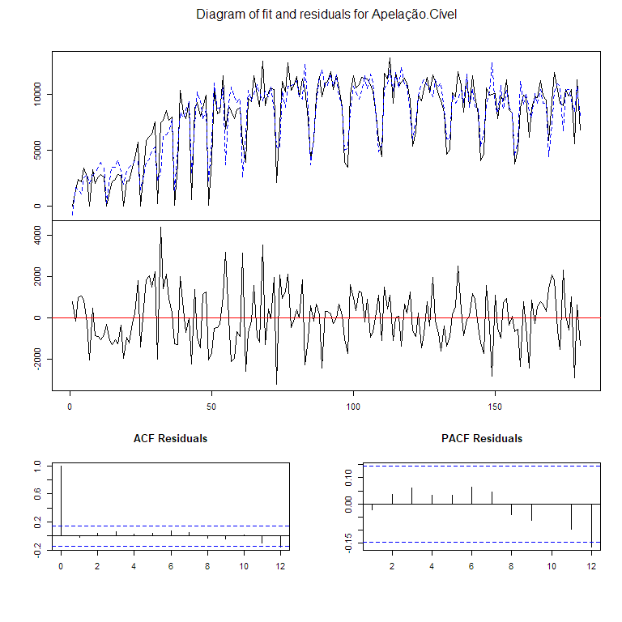

```r
plot(var.cymt.lag12, ask=FALSE)
```

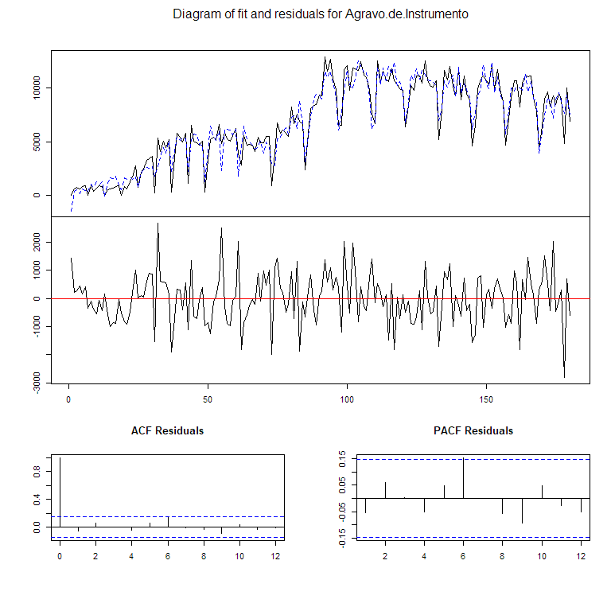

```r
NA
```

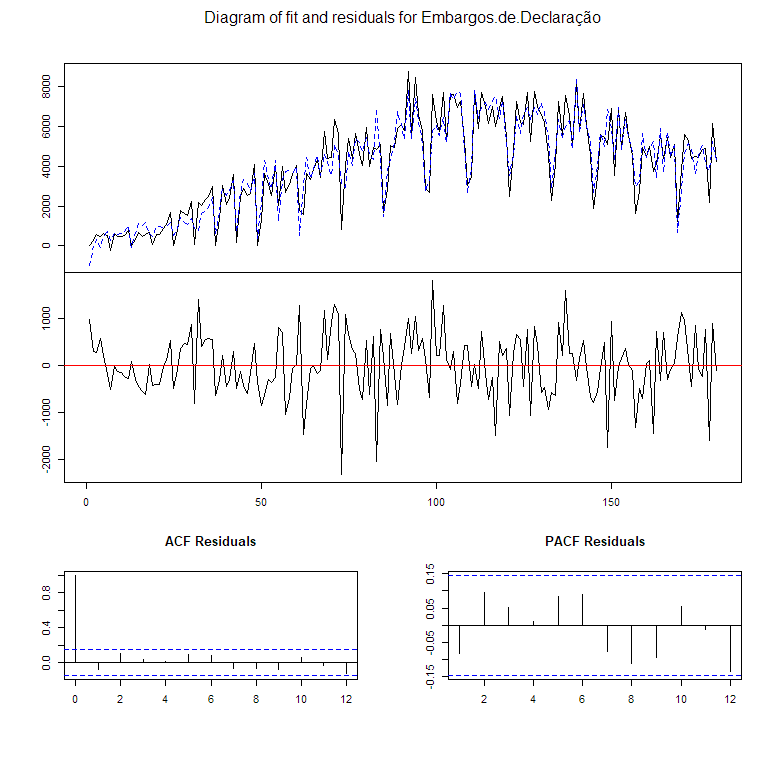

```r
NA
```

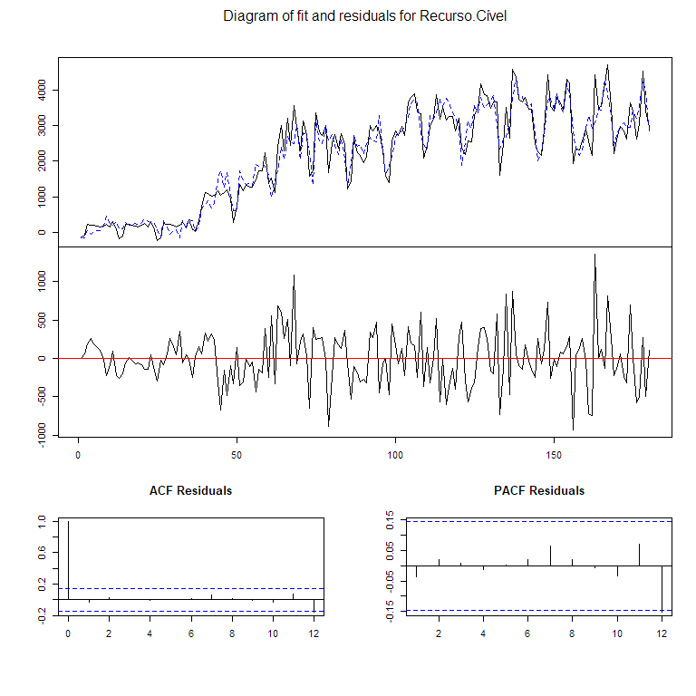

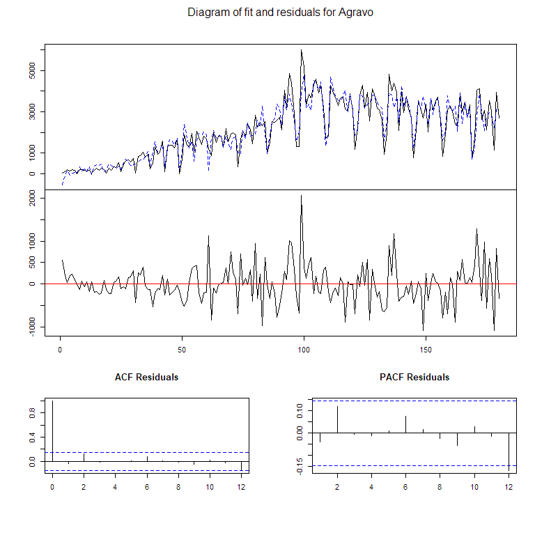

```r
NA
```

#### VAR permutações de 1, 3, 6 e 12 meses para lag.máximo e sazonalidade

A sazonalidade foi removida por não melhorar o modelo

```r
# lagmax - season - AIC - BIC - AIC(restrito) - BIC(restrito) - Objeto VAR - Objeto VAR restrito
# 1    -  1  - ...
# 1    -  6
# 1    -  12
# 3,6

# Períodos para teste
permutas <- c(1,3,6,12)

#Valor delimitante de significância para eliminar parâmetros desnecessários no modelo.
threshold.cut = 1.65

# Tibble contendo os valores de tabulados
tb.var <- tribble(
  ~lagmax, ~season, ~AIC, ~BIC, ~AIC.restrito, ~BIC.restrito
)
#Lista contendo os objetos VAR utilizados
var.models <- list()

# O parametro de sazonalidade não mostrou significância
# for (l in permutas) { # l para lag.max
#   for (s in permutas){ # s para season
#
#     # Verifica se a sazonalidade é 1 para considerar uso do parâmetro, pois gera erro ao executar explicitamente season=1
#     if (s==1) {
#       vs <- VARselect(ts_cymt_top5_as_vars, lag.max = l, type = "both")
#     }else {
#       vs <- VARselect(ts_cymt_top5_as_vars, lag.max = l, type = "both",season = s)
#     }
#
#     # Executa o VAR lagmax mais significativo avaliado no VARselect para o tipo AIC
#     var.l <- VAR(ts_cymt_top5_as_vars,type = "both",p=vs$selection[[1]])
#
#     # Executa a restrição do modelo para manter apenas as variáveis/relações mais significativas
#     var.l.rest <- restrict(var.l, method = "ser",thresh = threshold.cut)
#
#     # Anota os dados resultantes na tibble
#     tb.var <- tb.var %>% add_row(lagmax=l, season=s, AIC=AIC(var.l), BIC=BIC(var.l), AIC.restrito=AIC(var.l.rest), BIC.restrito=BIC(var.l.rest))
#
#     # Armazena os modelos utilizados em uma lista
#     var.models[[paste(paste0("S",s),paste0("L",l),"VAR",sep="_")]]<-var.l
#     var.models[[paste(paste0("S",s),paste0("L",l),"VARrestrito",sep="_")]]<-var.l.rest
#   }
# }

for (l in permutas) { # l para lag.max
  # Verifica se a sazonalidade é 1 para considerar uso do parâmetro, pois gera erro ao executar explicitamente season=1
  # if (s==1) {
    vs <- VARselect(ts_cymt_top5_vars_train, lag.max = l, type = "both")
  # }else {
  #   vs <- VARselect(ts_cymt_top5_as_vars, lag.max = l, type = "both",season = s)
  # }

  # Executa o VAR lagmax mais significativo avaliado no VARselect para o tipo AIC
  var.l <- VAR(ts_cymt_top5_vars_train,type = "both",p=vs$selection[[1]])

  # Executa a restrição do modelo para manter apenas as variáveis/relações mais significativas
  var.l.rest <- restrict(var.l, method = "ser",thresh = threshold.cut)

  # Anota os dados resultantes na tibble
  tb.var <- tb.var %>% add_row(lagmax=l, season=0, AIC=AIC(var.l), BIC=BIC(var.l), AIC.restrito=AIC(var.l.rest), BIC.restrito=BIC(var.l.rest))

  # Armazena os modelos utilizados em uma lista
  var.models[[paste(paste0("S",0),paste0("L",l),"VAR",sep="_")]]<-var.l
  var.models[[paste(paste0("S",0),paste0("L",l),"VARrestrito",sep="_")]]<-var.l.rest

}
```

```r
summary(var.models$S0_L12_VARrestrito)
```

```
VAR Estimation Results:
=========================
Endogenous variables: Apelação.Cível, Agravo.de.Instrumento, Embargos.de.Declaração, Recurso.Cível, Agravo
Deterministic variables: both
Sample size: 180
Log Likelihood: -7000.509
Roots of the characteristic polynomial:
1.007 0.9913 0.9913 0.9887 0.9887 0.9849 0.9849 0.9787 0.9787 0.9762 0.9762 0.9695 0.9695 0.9687 0.9687 0.9672 0.9672 0.9657 0.9636 0.9636 0.9553 0.9553 0.9553 0.9553 0.9552 0.9552 0.9479 0.9479 0.9458 0.9458 0.9451 0.9315 0.9315 0.9294 0.9294 0.9095 0.9095 0.9078 0.9078 0.904 0.904 0.8828 0.8828 0.…
Call:
VAR(y = ts_cymt_top5_vars_train, p = vs$selection[[1]], type = "both")


Estimation results for equation Apelação.Cível:
===============================================
Apelação.Cível = Apelação.Cível.l1 + Apelação.Cível.l6 + Agravo.l6 + Apelação.Cível.l8 + Agravo.de.Instrumento.l10 + Embargos.de.Declaração.l10 + Apelação.Cível.l11 + Agravo.de.Instrumento.l11 + Apelação.Cível.l12 + const

                             Estimate Std. Error t value Pr(>|t|)
Apelação.Cível.l1             0.13427    0.04743   2.831 0.005199 **
Apelação.Cível.l6             0.14542    0.06824   2.131 0.034526 *
Agravo.l6                    -0.35151    0.19903  -1.766 0.079178 .
Apelação.Cível.l8            -0.09999    0.04359  -2.294 0.023033 *
Agravo.de.Instrumento.l10     0.42407    0.13674   3.101 0.002256 **
Embargos.de.Declaração.l10   -0.58148    0.16207  -3.588 0.000436 ***
Apelação.Cível.l11            0.25860    0.08013   3.227 0.001499 **
Agravo.de.Instrumento.l11    -0.20692    0.11382  -1.818 0.070822 .
Apelação.Cível.l12            0.67532    0.05440  12.415  < 2e-16 ***
const                      1110.34754  362.86798   3.060 0.002573 **
---
Signif. codes:  0 ‘***’ 0.001 ‘**’ 0.01 ‘*’ 0.05 ‘.’ 0.1 ‘ ’ 1


Residual standard error: 1539 on 170 degrees of freedom
Multiple R-Squared:  0.97,  Adjusted R-squared: 0.9683
F-statistic:   550 on 10 and 170 DF,  p-value: < 2.2e-16


Estimation results for equation Agravo.de.Instrumento:
======================================================
Agravo.de.Instrumento = Apelação.Cível.l1 + Agravo.de.Instrumento.l1 + Agravo.l1 + Embargos.de.Declaração.l2 + Recurso.Cível.l2 + Embargos.de.Declaração.l4 + Recurso.Cível.l4 + Embargos.de.Declaração.l5 + Agravo.l5 + Apelação.Cível.l8 + Agravo.de.Instrumento.l8 + Embargos.de.Declaração.l9 + Agravo.l…

```

[output cut: 127 more lines]

```
Covariance matrix of residuals:
                       Apelação.Cível Agravo.de.Instrumento Embargos.de.Declaração Recurso.Cível Agravo
Apelação.Cível                3410382               1602849                1129435        193828 550541
Agravo.de.Instrumento         1602849               1474241                 785985        130967 476931
Embargos.de.Declaração        1129435                785985                 829001        113861 384159
Recurso.Cível                  193828                130967                 113861        222534  65065
Agravo                         550541                476931                 384159         65065 383651

Correlation matrix of residuals:
                       Apelação.Cível Agravo.de.Instrumento Embargos.de.Declaração Recurso.Cível Agravo
Apelação.Cível                 1.0000                0.7148                 0.6717        0.2225 0.4813
Agravo.de.Instrumento          0.7148                1.0000                 0.7110        0.2287 0.6342
Embargos.de.Declaração         0.6717                0.7110                 1.0000        0.2651 0.6812
Recurso.Cível                  0.2225                0.2287                 0.2651        1.0000 0.2227
Agravo                         0.4813                0.6342                 0.6812        0.2227 1.0000
```

Modelo AIC Lag 12 Var Threshold em relação à série original e resíduos

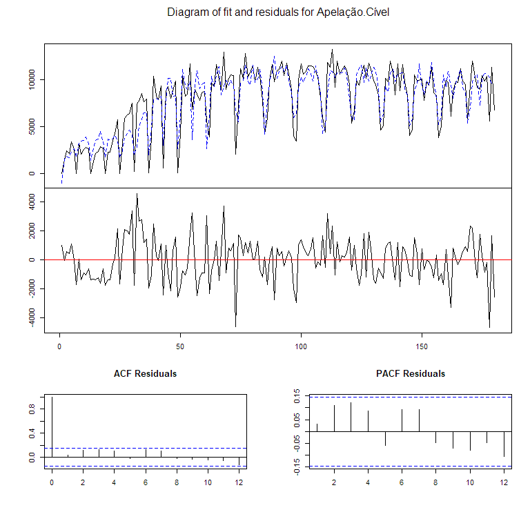

```r
plot(var.models$S0_L12_VARrestrito, ask=FALSE)
```

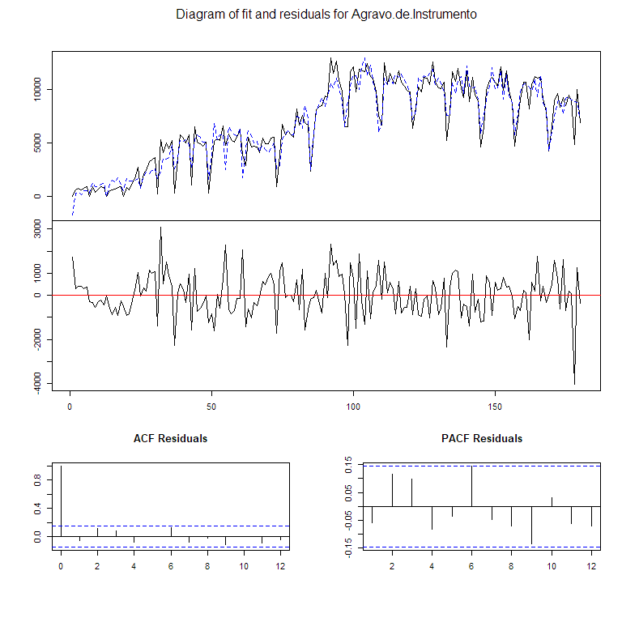

```r
NA
```

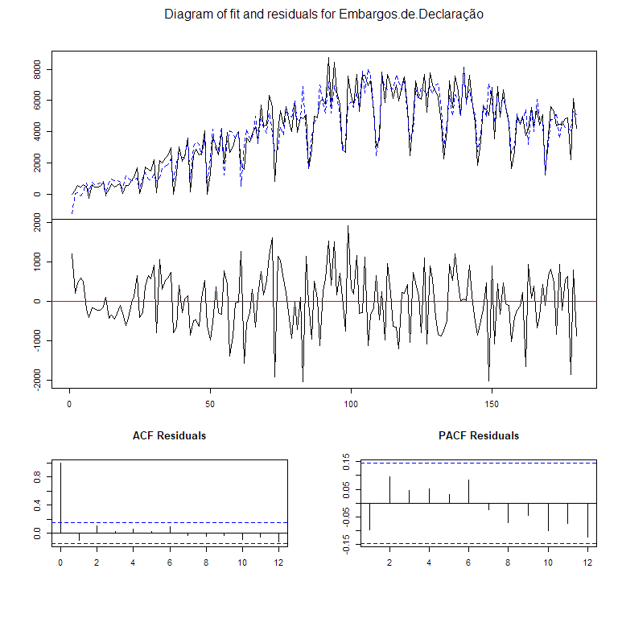

```r
NA
```

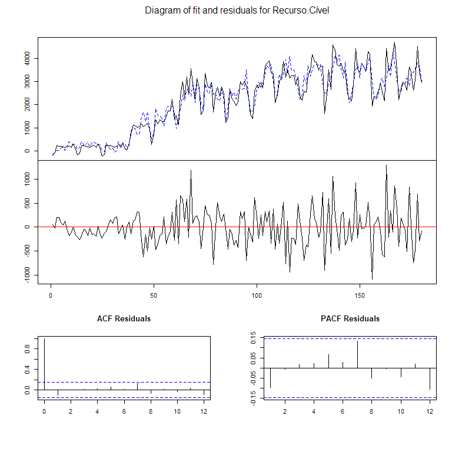

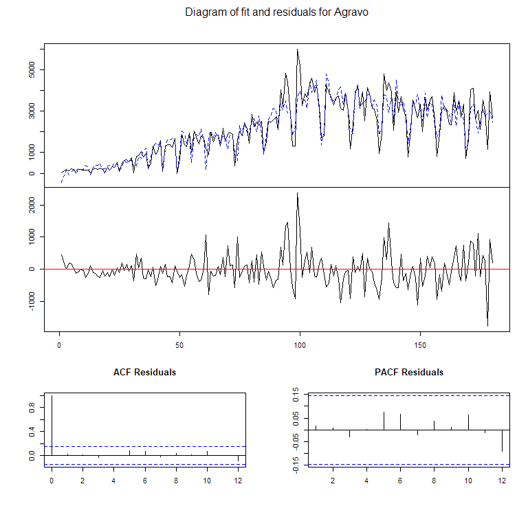

```r
NA
```

#### Modelo VAR utilizando lags especificadas manualmente (handpicked)

```r
var.cymt.hdp <- VAR(ts_cymt_top5_vars_train,type = "both",p=12)
# var.cymt12

#Matrix 5 x 62 - lags 1,3,6,12

restrict <- matrix(c(1,0,1,0,0,1,0,0,0,0,0,1,1,0,1,0,0,1,0,0,0,0,0,1,1,0,1,0,0,1,0,0,0,0,0,1,1,0,1,0,0,1,0,0,0,0,0,1,1,0,1,0,0,1,0,0,0,0,0,1,1,1,
1,0,1,0,0,1,0,0,0,0,0,1,1,0,1,0,0,1,0,0,0,0,0,1,1,0,1,0,0,1,0,0,0,0,0,1,1,0,1,0,0,1,0,0,0,0,0,1,1,0,1,0,0,1,0,0,0,0,0,1,1,1,
1,0,1,0,0,1,0,0,0,0,0,1,1,0,1,0,0,1,0,0,0,0,0,1,1,0,1,0,0,1,0,0,0,0,0,1,1,0,1,0,0,1,0,0,0,0,0,1,1,0,1,0,0,1,0,0,0,0,0,1,1,1,
1,0,1,0,0,1,0,0,0,0,0,1,1,0,1,0,0,1,0,0,0,0,0,1,1,0,1,0,0,1,0,0,0,0,0,1,1,0,1,0,0,1,0,0,0,0,0,1,1,0,1,0,0,1,0,0,0,0,0,1,1,1,
1,0,1,0,0,1,0,0,0,0,0,1,1,0,1,0,0,1,0,0,0,0,0,1,1,0,1,0,0,1,0,0,0,0,0,1,1,0,1,0,0,1,0,0,0,0,0,1,1,0,1,0,0,1,0,0,0,0,0,1,1,1),
                   nrow=5, ncol=62, byrow=TRUE)
var.cymt.aic.rest.hdp <-restrict(var.cymt.hdp, method = "man", resmat = restrict)

summary(var.cymt.aic.rest.hdp)
```

```
VAR Estimation Results:
=========================
Endogenous variables: Apelação.Cível, Agravo.de.Instrumento, Embargos.de.Declaração, Recurso.Cível, Agravo
Deterministic variables: both
Sample size: 180
Log Likelihood: -7118.512
Roots of the characteristic polynomial:
1.002 0.9872 0.9872 0.9706 0.9706 0.9701 0.9701 0.9626 0.9626 0.9375 0.9375 0.9324 0.9244 0.9055 0.9055 0.9048 0.9048 0.8957 0.8957 0.8888 0.8888 0.8784 0.8784 0.878 0.878 0.8694 0.8694 0.8599 0.8599 0.8515 0.8515 0.845 0.845 0.8431 0.8431 0.8346 0.8346 0.813 0.813 0.7877 0.7877 0.7825 0.7825 0.7601…
Call:
VAR(y = ts_cymt_top5_vars_train, p = 12, type = "both")


Estimation results for equation Apelação.Cível:
===============================================
Apelação.Cível = Apelação.Cível.l1 + Embargos.de.Declaração.l1 + Apelação.Cível.l2 + Agravo.de.Instrumento.l3 + Embargos.de.Declaração.l3 + Agravo.l3 + Embargos.de.Declaração.l4 + Recurso.Cível.l5 + Agravo.l5 + Agravo.de.Instrumento.l6 + Agravo.l6 + Apelação.Cível.l8 + Agravo.de.Instrumento.l8 + Rec…

                             Estimate Std. Error t value Pr(>|t|)
Apelação.Cível.l1             0.50284    0.11811   4.258 3.53e-05 ***
Embargos.de.Declaração.l1    -0.48640    0.20900  -2.327   0.0212 *
Apelação.Cível.l2             0.09607    0.07283   1.319   0.1890
Agravo.de.Instrumento.l3     -0.17535    0.20278  -0.865   0.3885
Embargos.de.Declaração.l3     0.51280    0.30014   1.709   0.0895 .
Agravo.l3                    -0.66711    0.44559  -1.497   0.1364
Embargos.de.Declaração.l4     0.11075    0.13305   0.832   0.4064
Recurso.Cível.l5             -0.10759    0.36530  -0.295   0.7687
Agravo.l5                    -0.33299    0.24664  -1.350   0.1789
Agravo.de.Instrumento.l6      0.41112    0.17765   2.314   0.0219 *
Agravo.l6                    -0.71734    0.38042  -1.886   0.0612 .
Apelação.Cível.l8            -0.01724    0.10680  -0.161   0.8720
Agravo.de.Instrumento.l8     -0.18680    0.16896  -1.106   0.2706
Recurso.Cível.l8              0.19251    0.39775   0.484   0.6291
Agravo.de.Instrumento.l9      0.15561    0.10982   1.417   0.1584
Embargos.de.Declaração.l10   -0.19363    0.16225  -1.193   0.2345
Recurso.Cível.l10            -0.44432    0.41130  -1.080   0.2817
Apelação.Cível.l11            0.32718    0.07573   4.321 2.74e-05 ***
Recurso.Cível.l11             0.12382    0.38856   0.319   0.7504
Agravo.l12                    1.57759    0.24085   6.550 7.68e-10 ***
const                      1362.22732  568.33628   2.397   0.0177 *
trend                        -6.09604   12.26625  -0.497   0.6199
---
```

[output cut: 153 more lines]

```
Covariance matrix of residuals:
                       Apelação.Cível Agravo.de.Instrumento Embargos.de.Declaração Recurso.Cível  Agravo
Apelação.Cível                5402340               2735093                2038828        387007 1002088
Agravo.de.Instrumento         2735093               2672657                1495436        154290  855234
Embargos.de.Declaração        2038828               1495436                1315629        179709  671654
Recurso.Cível                  387007                154290                 179709        340107   65555
Agravo                        1002088                855234                 671654         65555  513580

Correlation matrix of residuals:
                       Apelação.Cível Agravo.de.Instrumento Embargos.de.Declaração Recurso.Cível Agravo
Apelação.Cível                 1.0000                0.7198                 0.7648        0.2855 0.6016
Agravo.de.Instrumento          0.7198                1.0000                 0.7975        0.1618 0.7300
Embargos.de.Declaração         0.7648                0.7975                 1.0000        0.2687 0.8171
Recurso.Cível                  0.2855                0.1618                 0.2687        1.0000 0.1569
Agravo                         0.6016                0.7300                 0.8171        0.1569 1.0000
```

```r
AIC(var.cymt.aic.rest.hdp)
```

```
[1] 14457.02
```

```r
plot(var.cymt.aic.rest.hdp, ask=FALSE)
```

[output not shown]

```r
NA
```

```r
NA
```

```r
NA
```

```r
var.cymt.hdp <- VAR(ts_cymt_top5_vars_train,type = "both",p=12)
# var.cymt12

#Matrix 5 x 62 - Extra 1 - lags 1,3,6

restrict <- matrix(c(1,0,1,0,0,1,0,0,0,0,0,0,1,0,1,0,0,1,0,0,0,0,0,0,1,0,1,0,0,1,0,0,0,0,0,0,1,0,1,0,0,1,0,0,0,0,0,0,1,0,1,0,0,1,0,0,0,0,0,0,1,1,
1,0,1,0,0,1,0,0,0,0,0,0,1,0,1,0,0,1,0,0,0,0,0,0,1,0,1,0,0,1,0,0,0,0,0,0,1,0,1,0,0,1,0,0,0,0,0,0,1,0,1,0,0,1,0,0,0,0,0,0,1,1,
1,0,1,0,0,1,0,0,0,0,0,0,1,0,1,0,0,1,0,0,0,0,0,0,1,0,1,0,0,1,0,0,0,0,0,0,1,0,1,0,0,1,0,0,0,0,0,0,1,0,1,0,0,1,0,0,0,0,0,0,1,1,
1,0,1,0,0,1,0,0,0,0,0,0,1,0,1,0,0,1,0,0,0,0,0,0,1,0,1,0,0,1,0,0,0,0,0,0,1,0,1,0,0,1,0,0,0,0,0,0,1,0,1,0,0,1,0,0,0,0,0,0,1,1,
1,0,1,0,0,1,0,0,0,0,0,0,1,0,1,0,0,1,0,0,0,0,0,0,1,0,1,0,0,1,0,0,0,0,0,0,1,0,1,0,0,1,0,0,0,0,0,0,1,0,1,0,0,1,0,0,0,0,0,0,1,1),
                   nrow=5, ncol=62, byrow=TRUE)
var.cymt.aic.rest.hdp.ex1 <-restrict(var.cymt.hdp, method = "man", resmat = restrict)

summary(var.cymt.aic.rest.hdp)
```

```
VAR Estimation Results:
=========================
Endogenous variables: Apelação.Cível, Agravo.de.Instrumento, Embargos.de.Declaração, Recurso.Cível, Agravo
Deterministic variables: both
Sample size: 180
Log Likelihood: -7118.512
Roots of the characteristic polynomial:
1.002 0.9872 0.9872 0.9706 0.9706 0.9701 0.9701 0.9626 0.9626 0.9375 0.9375 0.9324 0.9244 0.9055 0.9055 0.9048 0.9048 0.8957 0.8957 0.8888 0.8888 0.8784 0.8784 0.878 0.878 0.8694 0.8694 0.8599 0.8599 0.8515 0.8515 0.845 0.845 0.8431 0.8431 0.8346 0.8346 0.813 0.813 0.7877 0.7877 0.7825 0.7825 0.7601…
Call:
VAR(y = ts_cymt_top5_vars_train, p = 12, type = "both")


Estimation results for equation Apelação.Cível:
===============================================
Apelação.Cível = Apelação.Cível.l1 + Embargos.de.Declaração.l1 + Apelação.Cível.l2 + Agravo.de.Instrumento.l3 + Embargos.de.Declaração.l3 + Agravo.l3 + Embargos.de.Declaração.l4 + Recurso.Cível.l5 + Agravo.l5 + Agravo.de.Instrumento.l6 + Agravo.l6 + Apelação.Cível.l8 + Agravo.de.Instrumento.l8 + Rec…

                             Estimate Std. Error t value Pr(>|t|)
Apelação.Cível.l1             0.50284    0.11811   4.258 3.53e-05 ***
Embargos.de.Declaração.l1    -0.48640    0.20900  -2.327   0.0212 *
Apelação.Cível.l2             0.09607    0.07283   1.319   0.1890
Agravo.de.Instrumento.l3     -0.17535    0.20278  -0.865   0.3885
Embargos.de.Declaração.l3     0.51280    0.30014   1.709   0.0895 .
Agravo.l3                    -0.66711    0.44559  -1.497   0.1364
Embargos.de.Declaração.l4     0.11075    0.13305   0.832   0.4064
Recurso.Cível.l5             -0.10759    0.36530  -0.295   0.7687
Agravo.l5                    -0.33299    0.24664  -1.350   0.1789
Agravo.de.Instrumento.l6      0.41112    0.17765   2.314   0.0219 *
Agravo.l6                    -0.71734    0.38042  -1.886   0.0612 .
Apelação.Cível.l8            -0.01724    0.10680  -0.161   0.8720
Agravo.de.Instrumento.l8     -0.18680    0.16896  -1.106   0.2706
Recurso.Cível.l8              0.19251    0.39775   0.484   0.6291
Agravo.de.Instrumento.l9      0.15561    0.10982   1.417   0.1584
Embargos.de.Declaração.l10   -0.19363    0.16225  -1.193   0.2345
Recurso.Cível.l10            -0.44432    0.41130  -1.080   0.2817
Apelação.Cível.l11            0.32718    0.07573   4.321 2.74e-05 ***
Recurso.Cível.l11             0.12382    0.38856   0.319   0.7504
Agravo.l12                    1.57759    0.24085   6.550 7.68e-10 ***
const                      1362.22732  568.33628   2.397   0.0177 *
trend                        -6.09604   12.26625  -0.497   0.6199
---
```

[output cut: 153 more lines]

```
Covariance matrix of residuals:
                       Apelação.Cível Agravo.de.Instrumento Embargos.de.Declaração Recurso.Cível  Agravo
Apelação.Cível                5402340               2735093                2038828        387007 1002088
Agravo.de.Instrumento         2735093               2672657                1495436        154290  855234
Embargos.de.Declaração        2038828               1495436                1315629        179709  671654
Recurso.Cível                  387007                154290                 179709        340107   65555
Agravo                        1002088                855234                 671654         65555  513580

Correlation matrix of residuals:
                       Apelação.Cível Agravo.de.Instrumento Embargos.de.Declaração Recurso.Cível Agravo
Apelação.Cível                 1.0000                0.7198                 0.7648        0.2855 0.6016
Agravo.de.Instrumento          0.7198                1.0000                 0.7975        0.1618 0.7300
Embargos.de.Declaração         0.7648                0.7975                 1.0000        0.2687 0.8171
Recurso.Cível                  0.2855                0.1618                 0.2687        1.0000 0.1569
Agravo                         0.6016                0.7300                 0.8171        0.1569 1.0000
```

```r
AIC(var.cymt.aic.rest.hdp)
```

```
[1] 14457.02
```

```r
plot(var.cymt.aic.rest.hdp, ask=FALSE)
```

[output not shown]

```r
NA
```

```r
NA
```

```r
NA
```

```r
var.cymt.hdp <- VAR(ts_cymt_top5_vars_train,type = "both",p=12)
# var.cymt12

#Matrix 5 x 62 - Extra 2 - lags 1 e 3

restrict <- matrix(c(1,0,1,0,0,0,0,0,0,0,0,0,1,0,1,0,0,0,0,0,0,0,0,0,1,0,1,0,0,0,0,0,0,0,0,0,1,0,1,0,0,0,0,0,0,0,0,0,1,0,1,0,0,0,0,0,0,0,0,0,1,1,
1,0,1,0,0,0,0,0,0,0,0,0,1,0,1,0,0,0,0,0,0,0,0,0,1,0,1,0,0,0,0,0,0,0,0,0,1,0,1,0,0,0,0,0,0,0,0,0,1,0,1,0,0,0,0,0,0,0,0,0,1,1,
1,0,1,0,0,0,0,0,0,0,0,0,1,0,1,0,0,0,0,0,0,0,0,0,1,0,1,0,0,0,0,0,0,0,0,0,1,0,1,0,0,0,0,0,0,0,0,0,1,0,1,0,0,0,0,0,0,0,0,0,1,1,
1,0,1,0,0,0,0,0,0,0,0,0,1,0,1,0,0,0,0,0,0,0,0,0,1,0,1,0,0,0,0,0,0,0,0,0,1,0,1,0,0,0,0,0,0,0,0,0,1,0,1,0,0,0,0,0,0,0,0,0,1,1,
1,0,1,0,0,0,0,0,0,0,0,0,1,0,1,0,0,0,0,0,0,0,0,0,1,0,1,0,0,0,0,0,0,0,0,0,1,0,1,0,0,0,0,0,0,0,0,0,1,0,1,0,0,0,0,0,0,0,0,0,1,1),
                   nrow=5, ncol=62, byrow=TRUE)
var.cymt.aic.rest.hdp.ex2 <-restrict(var.cymt.hdp, method = "man", resmat = restrict)

summary(var.cymt.aic.rest.hdp)
```

```
VAR Estimation Results:
=========================
Endogenous variables: Apelação.Cível, Agravo.de.Instrumento, Embargos.de.Declaração, Recurso.Cível, Agravo
Deterministic variables: both
Sample size: 180
Log Likelihood: -7118.512
Roots of the characteristic polynomial:
1.002 0.9872 0.9872 0.9706 0.9706 0.9701 0.9701 0.9626 0.9626 0.9375 0.9375 0.9324 0.9244 0.9055 0.9055 0.9048 0.9048 0.8957 0.8957 0.8888 0.8888 0.8784 0.8784 0.878 0.878 0.8694 0.8694 0.8599 0.8599 0.8515 0.8515 0.845 0.845 0.8431 0.8431 0.8346 0.8346 0.813 0.813 0.7877 0.7877 0.7825 0.7825 0.7601…
Call:
VAR(y = ts_cymt_top5_vars_train, p = 12, type = "both")


Estimation results for equation Apelação.Cível:
===============================================
Apelação.Cível = Apelação.Cível.l1 + Embargos.de.Declaração.l1 + Apelação.Cível.l2 + Agravo.de.Instrumento.l3 + Embargos.de.Declaração.l3 + Agravo.l3 + Embargos.de.Declaração.l4 + Recurso.Cível.l5 + Agravo.l5 + Agravo.de.Instrumento.l6 + Agravo.l6 + Apelação.Cível.l8 + Agravo.de.Instrumento.l8 + Rec…

                             Estimate Std. Error t value Pr(>|t|)
Apelação.Cível.l1             0.50284    0.11811   4.258 3.53e-05 ***
Embargos.de.Declaração.l1    -0.48640    0.20900  -2.327   0.0212 *
Apelação.Cível.l2             0.09607    0.07283   1.319   0.1890
Agravo.de.Instrumento.l3     -0.17535    0.20278  -0.865   0.3885
Embargos.de.Declaração.l3     0.51280    0.30014   1.709   0.0895 .
Agravo.l3                    -0.66711    0.44559  -1.497   0.1364
Embargos.de.Declaração.l4     0.11075    0.13305   0.832   0.4064
Recurso.Cível.l5             -0.10759    0.36530  -0.295   0.7687
Agravo.l5                    -0.33299    0.24664  -1.350   0.1789
Agravo.de.Instrumento.l6      0.41112    0.17765   2.314   0.0219 *
Agravo.l6                    -0.71734    0.38042  -1.886   0.0612 .
Apelação.Cível.l8            -0.01724    0.10680  -0.161   0.8720
Agravo.de.Instrumento.l8     -0.18680    0.16896  -1.106   0.2706
Recurso.Cível.l8              0.19251    0.39775   0.484   0.6291
Agravo.de.Instrumento.l9      0.15561    0.10982   1.417   0.1584
Embargos.de.Declaração.l10   -0.19363    0.16225  -1.193   0.2345
Recurso.Cível.l10            -0.44432    0.41130  -1.080   0.2817
Apelação.Cível.l11            0.32718    0.07573   4.321 2.74e-05 ***
Recurso.Cível.l11             0.12382    0.38856   0.319   0.7504
Agravo.l12                    1.57759    0.24085   6.550 7.68e-10 ***
const                      1362.22732  568.33628   2.397   0.0177 *
trend                        -6.09604   12.26625  -0.497   0.6199
---
```

[output cut: 153 more lines]

```
Covariance matrix of residuals:
                       Apelação.Cível Agravo.de.Instrumento Embargos.de.Declaração Recurso.Cível  Agravo
Apelação.Cível                5402340               2735093                2038828        387007 1002088
Agravo.de.Instrumento         2735093               2672657                1495436        154290  855234
Embargos.de.Declaração        2038828               1495436                1315629        179709  671654
Recurso.Cível                  387007                154290                 179709        340107   65555
Agravo                        1002088                855234                 671654         65555  513580

Correlation matrix of residuals:
                       Apelação.Cível Agravo.de.Instrumento Embargos.de.Declaração Recurso.Cível Agravo
Apelação.Cível                 1.0000                0.7198                 0.7648        0.2855 0.6016
Agravo.de.Instrumento          0.7198                1.0000                 0.7975        0.1618 0.7300
Embargos.de.Declaração         0.7648                0.7975                 1.0000        0.2687 0.8171
Recurso.Cível                  0.2855                0.1618                 0.2687        1.0000 0.1569
Agravo                         0.6016                0.7300                 0.8171        0.1569 1.0000
```

```r
AIC(var.cymt.aic.rest.hdp)
```

```
[1] 14457.02
```

```r
plot(var.cymt.aic.rest.hdp, ask=FALSE)
```

[output not shown]

```r
NA
```

```r
NA
```

```r
NA
```

#### Avaliação dos modelos em relação à própria série disponível

```r
# Função para converter retorno do varpd (Var Predict) em série temporal, para facilitar plot e cálculo de diferenças
varprd_to_ts <- function(varprd_org,startDate){
  #Validação das entradas
  stopifnot(class(varprd_org) == "varprd")
  stopifnot(class(startDate) == "Date" || class(as.Date(startDate)) == "Date" )

  #Extrair a lista apenas dos valores previstos
  lista <- lapply(varprd_org$fcst,'[',,1)

  #Calculo da data fim baseada no número de observações e data inicial
  endDate <- ymd(startDate)
  endDate %m+% months(length(lista$Agravo))

  #Realiza a conversão de cada item da lista em zooreg, inputando a data inicial e final, com a frequencia indicada em meses
  list_ts<-lapply(lista,zooreg,start = c(year(startDate),month(startDate)),end=c(year(endDate),month(endDate)),frequency = 12)

  # Realiza merge.zoo para tranformar a lista de séries em uma única série com diversas variáveis
  ts_resultado<- list_ts[[1]] %>% merge.zoo(list_ts[[2]])
  for (i in 3:5) { #Se for usar em outro contexto, trocar o 5 para extensão da lista
    ts_resultado<- ts_resultado %>% merge.zoo(list_ts[[i]])
  }

  #Renomear os nomes das variáveis
  colnames(ts_resultado) = names(lista)
  #Retorno
  ts_resultado
}
```

Obter os valores previstos e transformar em séries temporais

##### VAR Lag 12 Puro

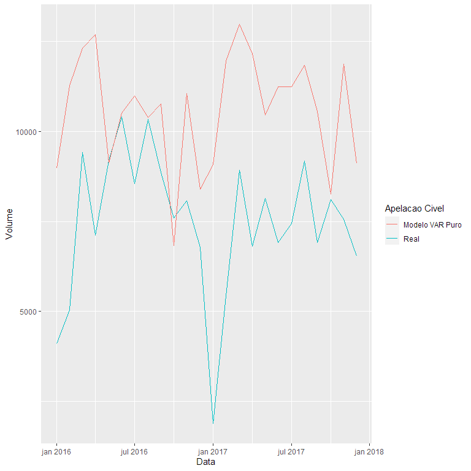

```r
x_fcast<-predict(var.models$S0_L12_VAR, n.ahead = 24, ci = 0.95, dumvar = NULL)

ts_modelo_varpuro<- varprd_to_ts(x_fcast,"2016-01-01")

# ts_cymt_top5_vars_test

#Apelacao Civel


p = ggplot() +
  geom_line(data = timetk::tk_tbl(ts_cymt_top5_vars_test$`Apelação Cível`,preserve_index=TRUE), aes(x = index, y = value,color="Real")) +
  geom_line(data = timetk::tk_tbl(ts_modelo_varpuro$Apelação.Cível,preserve_index=TRUE), aes(x = index, y = value,color="Modelo VAR Puro")) +
  xlab('Data') +
  ylab('Volume') +
  labs(color="Apelacao Civel")

print(p)
```

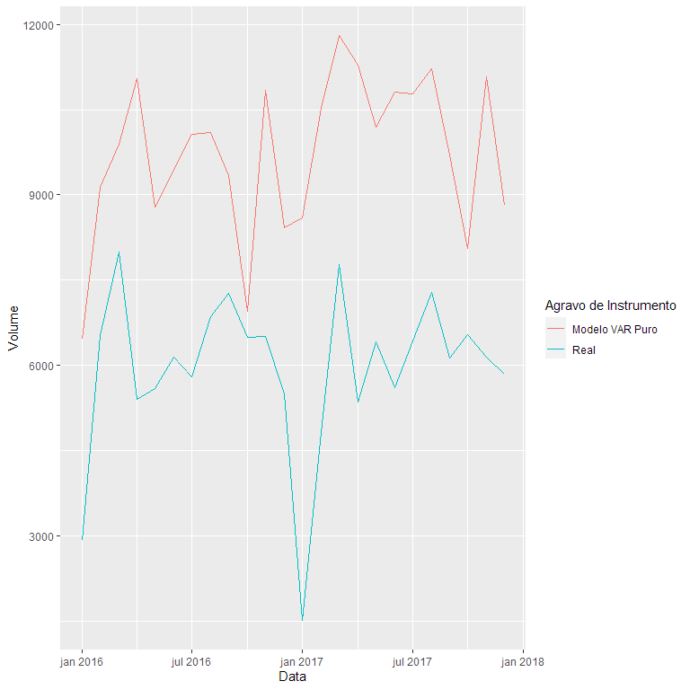

```r
#Agravo de Instrumento

p = ggplot() +
  geom_line(data = timetk::tk_tbl(ts_cymt_top5_vars_test$`Agravo de Instrumento`,preserve_index=TRUE), aes(x = index, y = value,color="Real")) +
  geom_line(data = timetk::tk_tbl(ts_modelo_varpuro$Agravo.de.Instrumento,preserve_index=TRUE), aes(x = index, y = value,color="Modelo VAR Puro")) +
  xlab('Data') +
  ylab('Volume') +
  labs(color="Agravo de Instrumento")

print(p)
```

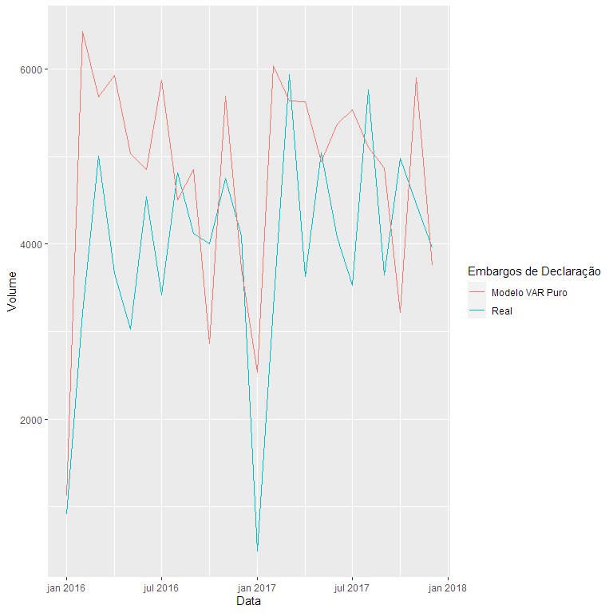

```r
#Embargos de Declaração

p = ggplot() +
  geom_line(data = timetk::tk_tbl(ts_cymt_top5_vars_test$`Embargos de Declaração`,preserve_index=TRUE), aes(x = index, y = value,color="Real")) +
  geom_line(data = timetk::tk_tbl(ts_modelo_varpuro$Embargos.de.Declaração ,preserve_index=TRUE), aes(x = index, y = value,color="Modelo VAR Puro")) +
  xlab('Data') +
  ylab('Volume') +
  labs(color="Embargos de Declaração")

print(p)
```

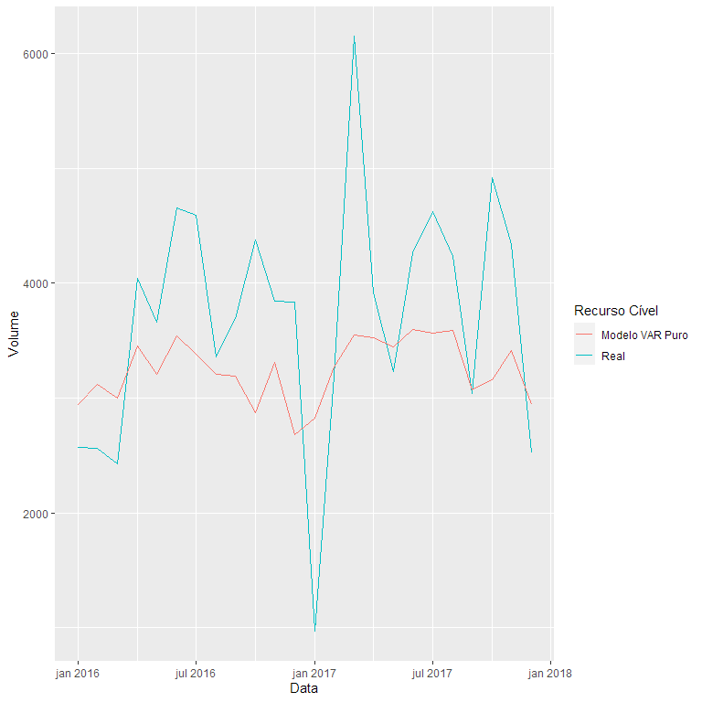

```r
#Recurso Cível
p = ggplot() +
  geom_line(data = timetk::tk_tbl(ts_cymt_top5_vars_test$`Recurso Cível`,preserve_index=TRUE), aes(x = index, y = value,color="Real")) +
  geom_line(data = timetk::tk_tbl(ts_modelo_varpuro$Recurso.Cível ,preserve_index=TRUE), aes(x = index, y = value,color="Modelo VAR Puro")) +
  xlab('Data') +
  ylab('Volume') +
  labs(color="Recurso Cível")

print(p)
```

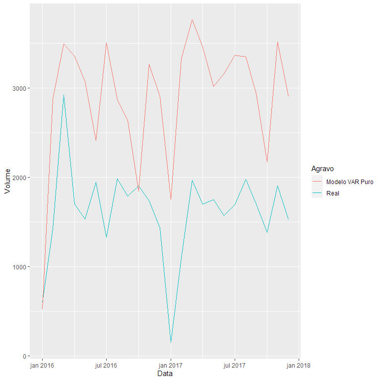

```r
#Agravo
p = ggplot() +
  geom_line(data = timetk::tk_tbl(ts_cymt_top5_vars_test$Agravo,preserve_index=TRUE), aes(x = index, y = value,color="Real")) +
  geom_line(data = timetk::tk_tbl(ts_modelo_varpuro$Agravo ,preserve_index=TRUE), aes(x = index, y = value,color="Modelo VAR Puro")) +
  xlab('Data') +
  ylab('Volume') +
  labs(color="Agravo")

print(p)
```

##### VAR Threshold

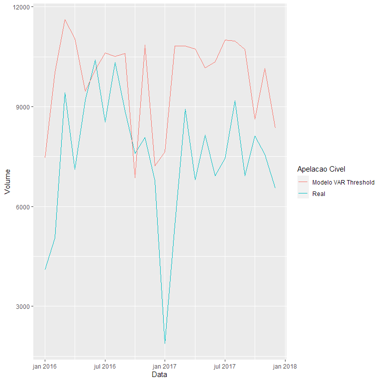

```r
x_fcast<-predict(var.models$S0_L12_VARrestrito, n.ahead = 24, ci = 0.95, dumvar = NULL)

ts_modelo_varthreshold<- varprd_to_ts(x_fcast,"2016-01-01")

# ts_cymt_top5_vars_test

#Apelacao Civel


p = ggplot() +
  geom_line(data = timetk::tk_tbl(ts_cymt_top5_vars_test$`Apelação Cível`,preserve_index=TRUE), aes(x = index, y = value,color="Real")) +
  geom_line(data = timetk::tk_tbl(ts_modelo_varthreshold$Apelação.Cível,preserve_index=TRUE), aes(x = index, y = value,color="Modelo VAR Threshold")) +
  xlab('Data') +
  ylab('Volume') +
  labs(color="Apelacao Civel")

print(p)
```

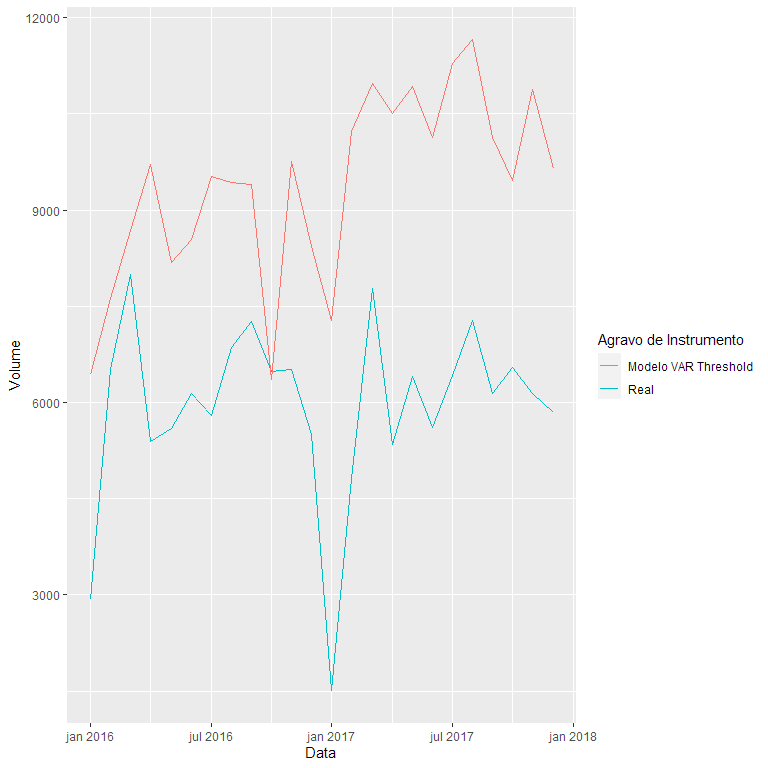

```r
#Agravo de Instrumento

p = ggplot() +
  geom_line(data = timetk::tk_tbl(ts_cymt_top5_vars_test$`Agravo de Instrumento`,preserve_index=TRUE), aes(x = index, y = value,color="Real")) +
  geom_line(data = timetk::tk_tbl(ts_modelo_varthreshold$Agravo.de.Instrumento,preserve_index=TRUE), aes(x = index, y = value,color="Modelo VAR Threshold")) +
  xlab('Data') +
  ylab('Volume') +
  labs(color="Agravo de Instrumento")

print(p)
```

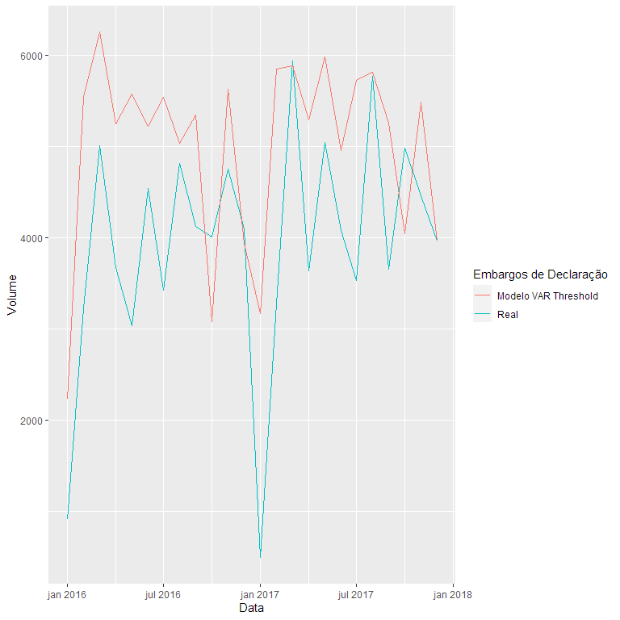

```r
#Embargos de Declaração

p = ggplot() +
  geom_line(data = timetk::tk_tbl(ts_cymt_top5_vars_test$`Embargos de Declaração`,preserve_index=TRUE), aes(x = index, y = value,color="Real")) +
  geom_line(data = timetk::tk_tbl(ts_modelo_varthreshold$Embargos.de.Declaração ,preserve_index=TRUE), aes(x = index, y = value,color="Modelo VAR Threshold")) +
  xlab('Data') +
  ylab('Volume') +
  labs(color="Embargos de Declaração")

print(p)
```

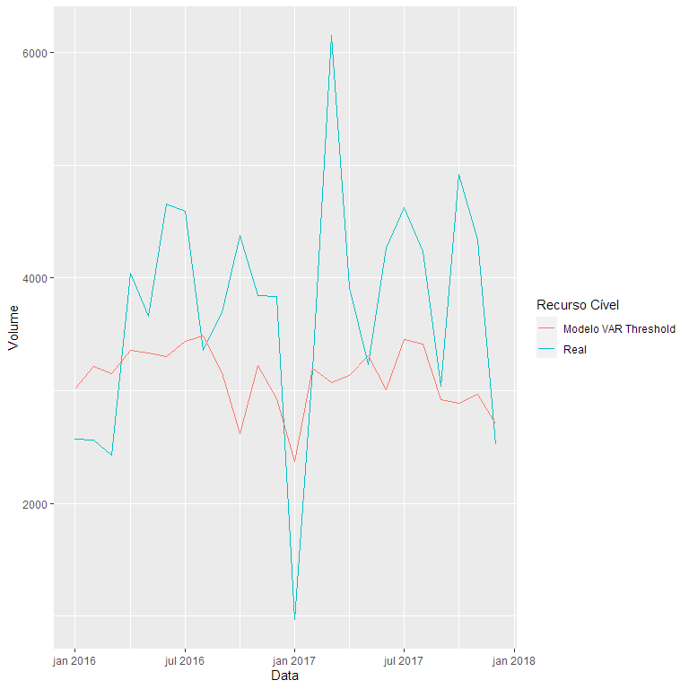

```r
#Recurso Cível
p = ggplot() +
  geom_line(data = timetk::tk_tbl(ts_cymt_top5_vars_test$`Recurso Cível`,preserve_index=TRUE), aes(x = index, y = value,color="Real")) +
  geom_line(data = timetk::tk_tbl(ts_modelo_varthreshold$Recurso.Cível ,preserve_index=TRUE), aes(x = index, y = value,color="Modelo VAR Threshold")) +
  xlab('Data') +
  ylab('Volume') +
  labs(color="Recurso Cível")

print(p)
```

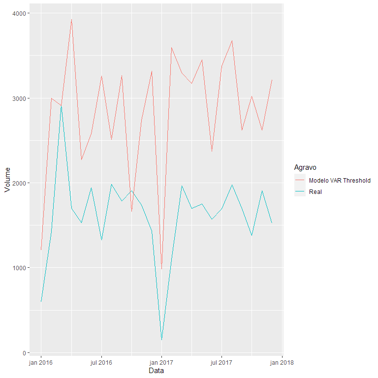

```r
#Agravo
p = ggplot() +
  geom_line(data = timetk::tk_tbl(ts_cymt_top5_vars_test$Agravo,preserve_index=TRUE), aes(x = index, y = value,color="Real")) +
  geom_line(data = timetk::tk_tbl(ts_modelo_varthreshold$Agravo ,preserve_index=TRUE), aes(x = index, y = value,color="Modelo VAR Threshold")) +
  xlab('Data') +
  ylab('Volume') +
  labs(color="Agravo")

print(p)
```

```r
NA
NA
```

##### VAR Handpicked

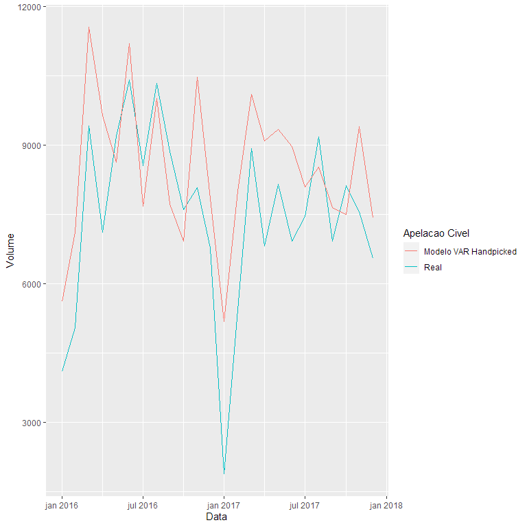

```r
x_fcast<-predict(var.cymt.aic.rest.hdp, n.ahead = 24, ci = 0.95, dumvar = NULL)

ts_modelo_varhdp<- varprd_to_ts(x_fcast,"2016-01-01")

# ts_cymt_top5_vars_test

#Apelacao Civel


p = ggplot() +
  geom_line(data = timetk::tk_tbl(ts_cymt_top5_vars_test$`Apelação Cível`,preserve_index=TRUE), aes(x = index, y = value,color="Real")) +
  geom_line(data = timetk::tk_tbl(ts_modelo_varhdp$Apelação.Cível,preserve_index=TRUE), aes(x = index, y = value,color="Modelo VAR Handpicked")) +
  xlab('Data') +
  ylab('Volume') +
  labs(color="Apelacao Civel")

print(p)
```

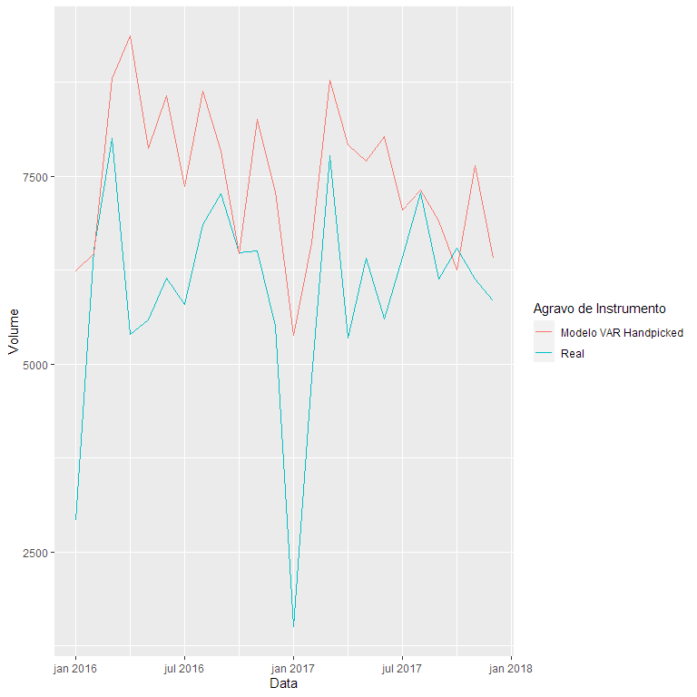

```r
#Agravo de Instrumento

p = ggplot() +
  geom_line(data = timetk::tk_tbl(ts_cymt_top5_vars_test$`Agravo de Instrumento`,preserve_index=TRUE), aes(x = index, y = value,color="Real")) +
  geom_line(data = timetk::tk_tbl(ts_modelo_varhdp$Agravo.de.Instrumento,preserve_index=TRUE), aes(x = index, y = value,color="Modelo VAR Handpicked")) +
  xlab('Data') +
  ylab('Volume') +
  labs(color="Agravo de Instrumento")

print(p)
```

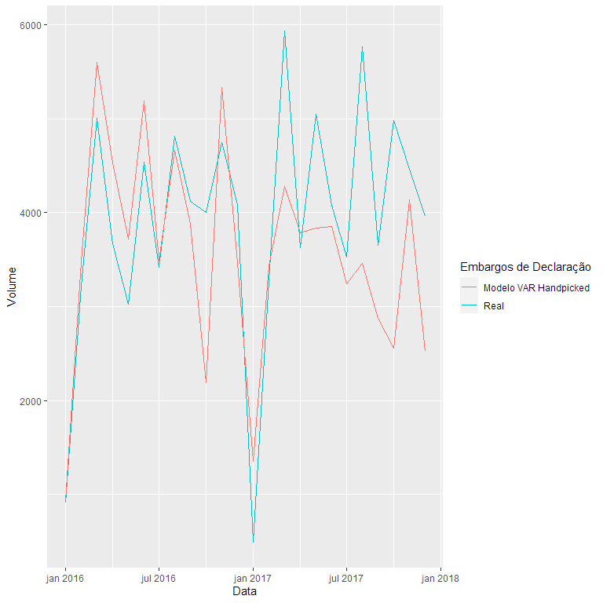

```r
#Embargos de Declaração

p = ggplot() +
  geom_line(data = timetk::tk_tbl(ts_cymt_top5_vars_test$`Embargos de Declaração`,preserve_index=TRUE), aes(x = index, y = value,color="Real")) +
  geom_line(data = timetk::tk_tbl(ts_modelo_varhdp$Embargos.de.Declaração ,preserve_index=TRUE), aes(x = index, y = value,color="Modelo VAR Handpicked")) +
  xlab('Data') +
  ylab('Volume') +
  labs(color="Embargos de Declaração")

print(p)
```

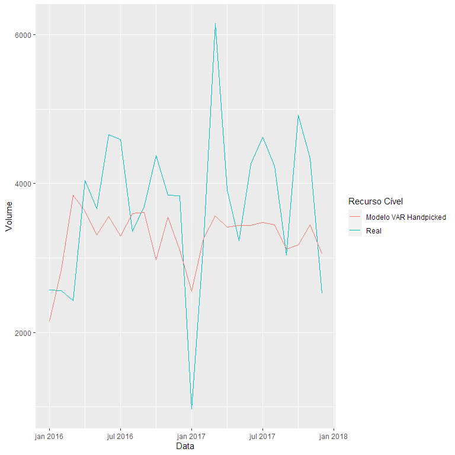

```r
#Recurso Cível
p = ggplot() +
  geom_line(data = timetk::tk_tbl(ts_cymt_top5_vars_test$`Recurso Cível`,preserve_index=TRUE), aes(x = index, y = value,color="Real")) +
  geom_line(data = timetk::tk_tbl(ts_modelo_varhdp$Recurso.Cível ,preserve_index=TRUE), aes(x = index, y = value,color="Modelo VAR Handpicked")) +
  xlab('Data') +
  ylab('Volume') +
  labs(color="Recurso Cível")

print(p)
```

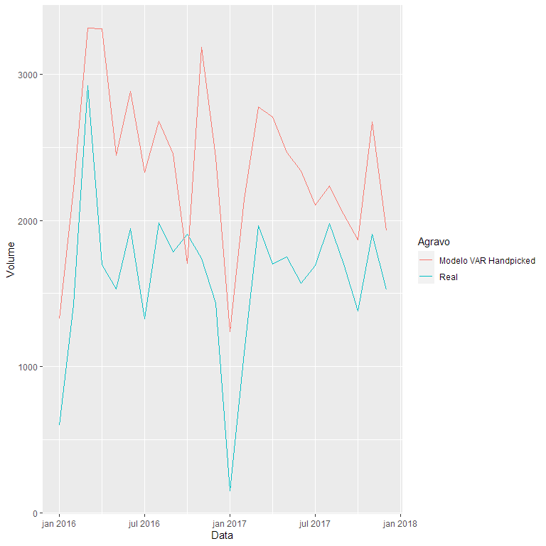

```r
#Agravo
p = ggplot() +
  geom_line(data = timetk::tk_tbl(ts_cymt_top5_vars_test$Agravo,preserve_index=TRUE), aes(x = index, y = value,color="Real")) +
  geom_line(data = timetk::tk_tbl(ts_modelo_varhdp$Agravo ,preserve_index=TRUE), aes(x = index, y = value,color="Modelo VAR Handpicked")) +
  xlab('Data') +
  ylab('Volume') +
  labs(color="Agravo")

print(p)
```

# Previsão de Extras 1 e 2 (sem plot comparativo com real)

```r
x_fcast<-predict(var.cymt.aic.rest.hdp.ex1, n.ahead = 24, ci = 0.95, dumvar = NULL)

ts_modelo_varhdp.ex1<- varprd_to_ts(x_fcast,"2016-01-01")

x_fcast<-predict(var.cymt.aic.rest.hdp.ex2, n.ahead = 24, ci = 0.95, dumvar = NULL)

ts_modelo_varhdp.ex2<- varprd_to_ts(x_fcast,"2016-01-01")
```

Calcular o erro baseado na diferença dos valores gerados em forecast para cada modelo

```r
#AIC - R2 - MAE - RMSE - MAPE

#AIC
paste0("AIC - Puro: ",AIC(var.models$S0_L12_VAR))
```

```
[1] "AIC - Puro: 14289.9342292457"
```

```r
paste0("AIC - Thresh: ",AIC(var.models$S0_L12_VARrestrito))
```

```
[1] "AIC - Thresh: 14169.0181878186"
```

```r
paste0("AIC - Hdpc: ",AIC(var.cymt.aic.rest.hdp))
```

```
[1] "AIC - Hdpc: 14457.0244096175"
```

```r
# MAE - Mean Absolute Error
paste0("MAE - Puro: ",mae(ts_cymt_top5_vars_test,ts_modelo_varpuro))
```

```
[1] "MAE - Puro: 2064.69137551162"
```

```r
paste0("MAE - thresh: ",mae(ts_cymt_top5_vars_test,ts_modelo_varthreshold))
```

```
[1] "MAE - thresh: 1861.00393112324"
```

```r
paste0("MAE - Hdpc: ",mae(ts_cymt_top5_vars_test,ts_modelo_varhdp))
```

```
[1] "MAE - Hdpc: 1057.55497018786"
```

```r
# RMSE - Root Mean Squared Error
paste0("RMSE - Puro: ",rmse(ts_cymt_top5_vars_test,ts_modelo_varpuro))
```

```
[1] "RMSE - Puro: 2696.4903691851"
```

```r
paste0("RMSE - thresh: ",rmse(ts_cymt_top5_vars_test,ts_modelo_varthreshold))
```

```
[1] "RMSE - thresh: 2371.530907312"
```

```r
paste0("RMSE - Hdpc: ",rmse(ts_cymt_top5_vars_test,ts_modelo_varhdp))
```

```
[1] "RMSE - Hdpc: 1347.71105052022"
```

```r
# MAPE - Mean Absolute Percentage Error
paste0("MAPE - Puro: ",mape(ts_cymt_top5_vars_test,ts_modelo_varpuro))
```

```
[1] "MAPE - Puro: 0.674333540140283"
```

```r
paste0("MAPE - thresh: ",mape(ts_cymt_top5_vars_test,ts_modelo_varthreshold))
```

```
[1] "MAPE - thresh: 0.611263165477041"
```

```r
paste0("MAPE - Hdpc: ",mape(ts_cymt_top5_vars_test,ts_modelo_varhdp))
```

```
[1] "MAPE - Hdpc: 0.379660433057416"
```

```r
# MASE - Mean Absolute Scaled Error
paste0("MASE - Puro: ",mase(ts(ts_cymt_top5_vars_test),ts(ts_modelo_varpuro),step_size=12))
```

```
[1] "MASE - Puro: 1.84201252771656"
```

```r
paste0("MASE - thresh: ",mase(ts(ts_cymt_top5_vars_test),ts(ts_modelo_varthreshold),step_size=12))
```

```
[1] "MASE - thresh: 1.66029295996324"
```

```r
paste0("MASE - Hdpc: ",mase(ts(ts_cymt_top5_vars_test),ts(ts_modelo_varhdp),step_size=12))
```

```
[1] "MASE - Hdpc: 0.943496702189807"
```

```r
#R2 e ADJUSTED R2 - Separado
paste0("R²: ",lapply(summary(var.models$S0_L12_VAR)$varresult, "[", "r.squared"))
```

```
[1] "R²: list(r.squared = 0.850864107661177)" "R²: list(r.squared = 0.942956316668729)" "R²: list(r.squared = 0.912389657667434)" "R²: list(r.squared = 0.929790638463023)"
[5] "R²: list(r.squared = 0.896049384379428)"
```

```r
paste0("Adjusted R²: ",lapply(summary(var.models$S0_L12_VAR)$varresult, "[", "adj.r.squared"))
```

```
[1] "Adjusted R²: list(adj.r.squared = 0.773768434502971)" "Adjusted R²: list(adj.r.squared = 0.913467632912733)" "Adjusted R²: list(adj.r.squared = 0.867099565444667)"
[4] "Adjusted R²: list(adj.r.squared = 0.893495968515941)" "Adjusted R²: list(adj.r.squared = 0.842312201728116)"
```

```r
paste0("R²: ",lapply(summary(var.models$S0_L12_VARrestrito)$varresult, "[", "r.squared"))
```

```
[1] "R²: list(r.squared = 0.970017874358077)" "R²: list(r.squared = 0.983875990826133)" "R²: list(r.squared = 0.974338750438439)" "R²: list(r.squared = 0.977217829056256)"
[5] "R²: list(r.squared = 0.960724306289333)"
```

```r
paste0("Adjusted R²: ",lapply(summary(var.models$S0_L12_VARrestrito)$varresult, "[", "adj.r.squared"))
```

```
[1] "Adjusted R²: list(adj.r.squared = 0.968254219908552)" "Adjusted R²: list(adj.r.squared = 0.982084434251259)" "Adjusted R²: list(adj.r.squared = 0.970579459101395)"
[4] "Adjusted R²: list(adj.r.squared = 0.975296441145338)" "Adjusted R²: list(adj.r.squared = 0.956089286534658)"
```

```r
paste0("R²: ",lapply(summary(var.cymt.aic.rest.hdp)$varresult, "[", "r.squared"))
```

```
[1] "R²: list(r.squared = 0.952505718117228)" "R²: list(r.squared = 0.970773807161776)" "R²: list(r.squared = 0.959276268783411)" "R²: list(r.squared = 0.965191973526898)"
[5] "R²: list(r.squared = 0.947427205013277)"
```

```r
paste0("Adjusted R²: ",lapply(summary(var.cymt.aic.rest.hdp)$varresult, "[", "adj.r.squared"))
```

```
[1] "Adjusted R²: list(adj.r.squared = 0.945892590260134)" "Adjusted R²: list(adj.r.squared = 0.966704337272909)" "Adjusted R²: list(adj.r.squared = 0.953605875829202)"
[4] "Adjusted R²: list(adj.r.squared = 0.960345286296466)" "Adjusted R²: list(adj.r.squared = 0.940106942420189)"
```

```r
# Tabela de avaliação dos modelos
tb.eval <- tribble(
  ~model, ~aic, ~bic, ~mae, ~rmse, ~mape, ~mase
)

#Puro - Lagmax 12
tb.eval <- tb.eval %>% add_row(model="VAR - Lag12 - Puro", aic=AIC(var.models$S0_L12_VAR), bic=BIC(var.models$S0_L12_VAR), mae=mae(ts_cymt_top5_vars_test,ts_modelo_varpuro),rmse=rmse(ts_cymt_top5_vars_test,ts_modelo_varpuro),mape=mape(ts_cymt_top5_vars_test,ts_modelo_varpuro),mase=mase(ts(ts_cymt_top5_vars_test),ts(ts_modelo_varpuro),step_size=12))

#Restrito - Lagmax 12 - Threshold p>1.65
tb.eval <- tb.eval %>% add_row(model=paste0("VAR - Lag 12 - Restrito - Threshold p>",threshold.cut), aic=AIC(var.models$S0_L12_VARrestrito), bic=BIC(var.models$S0_L12_VARrestrito), mae=mae(ts_cymt_top5_vars_test,ts_modelo_varthreshold),rmse=rmse(ts_cymt_top5_vars_test,ts_modelo_varthreshold),mape=mape(ts_cymt_top5_vars_test,ts_modelo_varthreshold),mase=mase(ts(ts_cymt_top5_vars_test),ts(ts_modelo_varthreshold),step_size=12))

#Restrito - Lagmax 12 - Handpicked lags (1,3,6,12)
tb.eval <- tb.eval %>% add_row(model="VAR - Lag12 - Restrito - Handpicked lags (1,3,6,12)", aic=AIC(var.cymt.aic.rest.hdp), bic=BIC(var.cymt.aic.rest.hdp), mae=mae(ts_cymt_top5_vars_test,ts_modelo_varhdp),rmse=rmse(ts_cymt_top5_vars_test,ts_modelo_varhdp),mape=mape(ts_cymt_top5_vars_test,ts_modelo_varhdp),mase=mase(ts(ts_cymt_top5_vars_test),ts(ts_modelo_varhdp),step_size=12))

#Restrito - Lagmax 12 - Extra 1 - Handpicked lags (1,3,6)
tb.eval <- tb.eval %>% add_row(model="VAR - Lag12 - Restrito - Extra 1 - Handpicked lags (1,3,6)", aic=AIC(var.cymt.aic.rest.hdp.ex1), bic=BIC(var.cymt.aic.rest.hdp.ex1), mae=mae(ts_cymt_top5_vars_test,ts_modelo_varhdp.ex1),rmse=rmse(ts_cymt_top5_vars_test,ts_modelo_varhdp.ex1),mape=mape(ts_cymt_top5_vars_test,ts_modelo_varhdp.ex1),mase=mase(ts(ts_cymt_top5_vars_test),ts(ts_modelo_varhdp.ex1),step_size=12))

#Restrito - Lagmax 12 - Extra 2 - Handpicked lags (1,3)
tb.eval <- tb.eval %>% add_row(model="VAR - Lag12 - Restrito - Extra 2 - Handpicked lags (1,3)", aic=AIC(var.cymt.aic.rest.hdp.ex2), bic=BIC(var.cymt.aic.rest.hdp.ex2), mae=mae(ts_cymt_top5_vars_test,ts_modelo_varhdp.ex2),rmse=rmse(ts_cymt_top5_vars_test,ts_modelo_varhdp.ex2),mape=mape(ts_cymt_top5_vars_test,ts_modelo_varhdp.ex2),mase=mase(ts(ts_cymt_top5_vars_test),ts(ts_modelo_varhdp.ex2),step_size=12))

tb.eval
```

| model | aic | bic | mae | rmse | mape | mase |
| --- | --- | --- | --- | --- | --- | --- |
| VAR - Lag12 - Puro | 14289.93 | 15279.75 | 2064.691 | 2696.490 | 0.6743335 | 1.8420125 |
| VAR - Lag 12 - Restrito - Threshold p>1.65 | 14169.02 | 14437.23 | 1861.004 | 2371.531 | 0.6112632 | 1.6602930 |
| VAR - Lag12 - Restrito - Handpicked lags (1,3,6,12) | 14457.02 | 14808.25 | 1057.555 | 1347.711 | 0.3796604 | 0.9434967 |
| VAR - Lag12 - Restrito - Extra 1 - Handpicked lags (1,3,6) | 14559.81 | 14831.22 | 1343.533 | 1806.650 | 0.6329620 | 1.1986319 |
| VAR - Lag12 - Restrito - Extra 2 - Handpicked lags (1,3) | 14584.42 | 14776.00 | 1888.760 | 2492.513 | 0.8314523 | 1.6850558 |

```r
# Tabela de R² e R² Ajustado para os modelos
tb.r2 <- tribble(
  ~model, ~apelacao.civel.rsq,~apelacao.civel.adj.rsq, ~agravo.de.instrumento.rsq, ~agravo.de.instrumento.adj.rsq, ~embargos.de.declaracao.rsq, ~embargos.de.declaracao.adj.rsq, ~recurso.civel.rsq, ~recurso.civel.adj.rsq, ~agravo.rsq, ~agravo.adj.rsq
)

# R2 - Puro - Lagmax 12
r2<-lapply(summary(var.models$S0_L12_VAR)$varresult, "[", "r.squared")
r2.adj<-lapply(summary(var.models$S0_L12_VAR)$varresult, "[", "adj.r.squared")

tb.r2 <- tb.r2 %>% add_row(model="VAR - Lag12 - Puro",apelacao.civel.rsq=r2$Apelação.Cível$r.squared, apelacao.civel.adj.rsq= r2.adj$Apelação.Cível$adj.r.squared, agravo.de.instrumento.rsq=r2$Agravo.de.Instrumento$r.squared, agravo.de.instrumento.adj.rsq=r2.adj$Agravo.de.Instrumento$adj.r.squared, embargos.de.declaracao.rsq=r2$Embargos.de.Declaração$r.squared, embargos.de.declaracao.adj.rsq=r2.adj$Embargos.de.Declaração$adj.r.squared, recurso.civel.rsq=r2$Recurso.Cível$r.squared, recurso.civel.adj.rsq=r2.adj$Recurso.Cível$adj.r.squared, agravo.rsq=r2$Agravo$r.squared, agravo.adj.rsq=r2.adj$Agravo$adj.r.squared )

# R2 - Restrito - Lagmax 12 - Threshold
r2<-lapply(summary(var.models$S0_L12_VARrestrito)$varresult, "[", "r.squared")
r2.adj<-lapply(summary(var.models$S0_L12_VARrestrito)$varresult, "[", "adj.r.squared")

tb.r2 <- tb.r2 %>% add_row(model=paste0("VAR - Lag12 - Restrito - p>",threshold.cut),apelacao.civel.rsq=r2$Apelação.Cível$r.squared, apelacao.civel.adj.rsq= r2.adj$Apelação.Cível$adj.r.squared, agravo.de.instrumento.rsq=r2$Agravo.de.Instrumento$r.squared, agravo.de.instrumento.adj.rsq=r2.adj$Agravo.de.Instrumento$adj.r.squared, embargos.de.declaracao.rsq=r2$Embargos.de.Declaração$r.squared, embargos.de.declaracao.adj.rsq=r2.adj$Embargos.de.Declaração$adj.r.squared, recurso.civel.rsq=r2$Recurso.Cível$r.squared, recurso.civel.adj.rsq=r2.adj$Recurso.Cível$adj.r.squared, agravo.rsq=r2$Agravo$r.squared, agravo.adj.rsq=r2.adj$Agravo$adj.r.squared )

# R2 - Restrito - Lagmax 12 - Handpicked lags (1,3,6,12)
r2<-lapply(summary(var.cymt.aic.rest.hdp)$varresult, "[", "r.squared")
r2.adj<-lapply(summary(var.cymt.aic.rest.hdp)$varresult, "[", "adj.r.squared")

tb.r2 <- tb.r2 %>% add_row(model="VAR - Lag12 - Handpicked lags (1,3,6,12)",apelacao.civel.rsq=r2$Apelação.Cível$r.squared, apelacao.civel.adj.rsq= r2.adj$Apelação.Cível$adj.r.squared, agravo.de.instrumento.rsq=r2$Agravo.de.Instrumento$r.squared, agravo.de.instrumento.adj.rsq=r2.adj$Agravo.de.Instrumento$adj.r.squared, embargos.de.declaracao.rsq=r2$Embargos.de.Declaração$r.squared, embargos.de.declaracao.adj.rsq=r2.adj$Embargos.de.Declaração$adj.r.squared, recurso.civel.rsq=r2$Recurso.Cível$r.squared, recurso.civel.adj.rsq=r2.adj$Recurso.Cível$adj.r.squared, agravo.rsq=r2$Agravo$r.squared, agravo.adj.rsq=r2.adj$Agravo$adj.r.squared )

# R2 - Restrito - Lagmax 12 - Extra 1 - Handpicked lags (1,3,6)
r2<-lapply(summary(var.cymt.aic.rest.hdp.ex1)$varresult, "[", "r.squared")
r2.adj<-lapply(summary(var.cymt.aic.rest.hdp.ex1)$varresult, "[", "adj.r.squared")

tb.r2 <- tb.r2 %>% add_row(model="VAR - Lag12 - Extra 1 - Handpicked lags (1,3,6)",apelacao.civel.rsq=r2$Apelação.Cível$r.squared, apelacao.civel.adj.rsq= r2.adj$Apelação.Cível$adj.r.squared, agravo.de.instrumento.rsq=r2$Agravo.de.Instrumento$r.squared, agravo.de.instrumento.adj.rsq=r2.adj$Agravo.de.Instrumento$adj.r.squared, embargos.de.declaracao.rsq=r2$Embargos.de.Declaração$r.squared, embargos.de.declaracao.adj.rsq=r2.adj$Embargos.de.Declaração$adj.r.squared, recurso.civel.rsq=r2$Recurso.Cível$r.squared, recurso.civel.adj.rsq=r2.adj$Recurso.Cível$adj.r.squared, agravo.rsq=r2$Agravo$r.squared, agravo.adj.rsq=r2.adj$Agravo$adj.r.squared )

# R2 - Restrito - Lagmax 12 - Extra 2 - Handpicked lags (1,3)
r2<-lapply(summary(var.cymt.aic.rest.hdp.ex2)$varresult, "[", "r.squared")
r2.adj<-lapply(summary(var.cymt.aic.rest.hdp.ex2)$varresult, "[", "adj.r.squared")

tb.r2 <- tb.r2 %>% add_row(model="VAR - Lag12 - Extra 2 - Handpicked lags (1,3)",apelacao.civel.rsq=r2$Apelação.Cível$r.squared, apelacao.civel.adj.rsq= r2.adj$Apelação.Cível$adj.r.squared, agravo.de.instrumento.rsq=r2$Agravo.de.Instrumento$r.squared, agravo.de.instrumento.adj.rsq=r2.adj$Agravo.de.Instrumento$adj.r.squared, embargos.de.declaracao.rsq=r2$Embargos.de.Declaração$r.squared, embargos.de.declaracao.adj.rsq=r2.adj$Embargos.de.Declaração$adj.r.squared, recurso.civel.rsq=r2$Recurso.Cível$r.squared, recurso.civel.adj.rsq=r2.adj$Recurso.Cível$adj.r.squared, agravo.rsq=r2$Agravo$r.squared, agravo.adj.rsq=r2.adj$Agravo$adj.r.squared )


# Exibir tabela de R² e R² ajustado
tb.r2
```

| model | apelacao.civel.rsq | apelacao.civel.adj.rsq | agravo.de.instrumento.rsq | agravo.de.instrumento.adj.rsq | embargos.de.declaracao.rsq | embargos.de.declaracao.adj.rsq | recurso.civel.rsq | recurso.civel.adj.rsq | agravo.rsq | agravo.adj.rsq |
| --- | --- | --- | --- | --- | --- | --- | --- | --- | --- | --- |
| VAR - Lag12 - Puro | 0.8508641 | 0.7737684 | 0.9429563 | 0.9134676 | 0.9123897 | 0.8670996 | 0.9297906 | 0.8934960 | 0.8960494 | 0.8423122 |
| VAR - Lag12 - Restrito - p>1.65 | 0.9700179 | 0.9682542 | 0.9838760 | 0.9820844 | 0.9743388 | 0.9705795 | 0.9772178 | 0.9752964 | 0.9607243 | 0.9560893 |
| VAR - Lag12 - Handpicked lags (1,3,6,12) | 0.9525057 | 0.9458926 | 0.9707738 | 0.9667043 | 0.9592763 | 0.9536059 | 0.9651920 | 0.9603453 | 0.9474272 | 0.9401069 |
| VAR - Lag12 - Extra 1 - Handpicked lags (1,3,6) | 0.9386255 | 0.9322245 | 0.9573841 | 0.9529395 | 0.9306421 | 0.9234085 | 0.9584217 | 0.9540853 | 0.9219022 | 0.9137570 |
| VAR - Lag12 - Extra 2 - Handpicked lags (1,3) | 0.9364649 | 0.9319267 | 0.9529575 | 0.9495973 | 0.9242933 | 0.9188857 | 0.9546028 | 0.9513602 | 0.9155962 | 0.9095673 |

```r
NA
```

### Impulso (Não considerar)

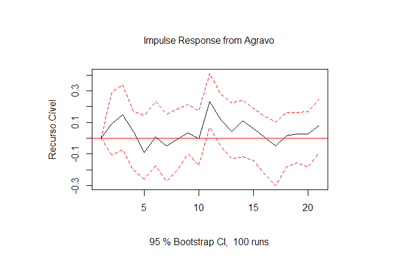

```r
# Gráficos de reposta de impulso

ir.1 <- irf(var.models$S0_L12_VARrestrito, impulse = "Agravo", response = "Recurso.Cível", n.ahead = 20, ortho = FALSE)
plot(ir.1)
```

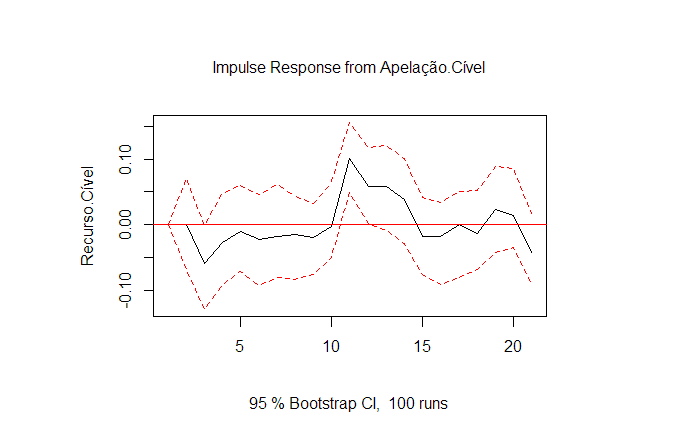

```r
ir.2 <- irf(var.models$S0_L12_VARrestrito, impulse = "Apelação.Cível", response = "Recurso.Cível", n.ahead = 20, ortho = FALSE)
plot(ir.2)
```

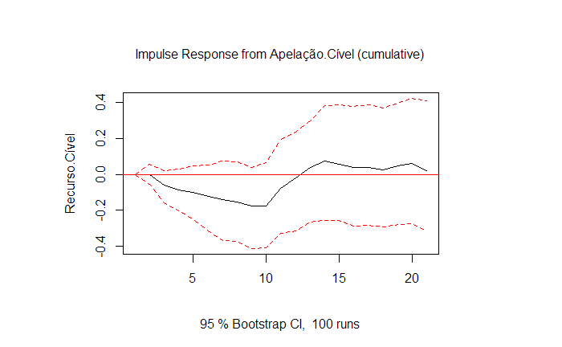

```r
ir.3 <- irf(var.models$S0_L12_VARrestrito,impulse="Apelação.Cível",response="Recurso.Cível",n.ahead = 20,ortho = FALSE,cumulative = TRUE)
plot(ir.3)
```

### CDT (Count Day Type)

```r
# var.cdt <- VAR(ts_cdt_top5_as_vars,type = "none")
# var.cdt
#
# VARselect(ts_cdt_top5_as_vars, lag.max = 10, type = "both", season=7)
```

```r
# var.cdt.aic <- VAR(ts_cdt_top5_as_vars, type = "none", lag.max = 10, ic = "SC")
# summary(var.cdt.aic)
```

# Partes sugeridas pelo professor

## Pairs Mês Ano

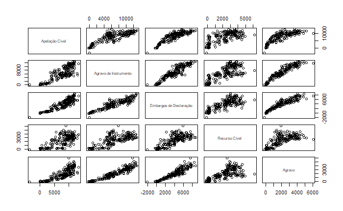

```r
pairs(ts_cymt_top5_vars)
```

## Pairs Diário

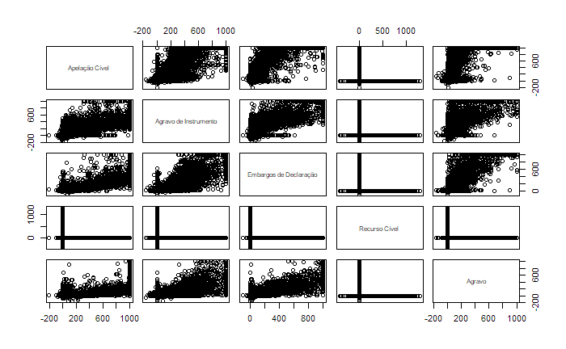

```r
# pairs para top5
pairs(ts_cdt_top5_as_vars)
```

```r
NA
NA
NA
```

## Avaliação de algoritmos de predição

```r
ts_cymt_top5_agg<- ts_ts(cymt_top5_agg)
```

```
[time]: 'Group.yearMonth' [value]: 'count'
```

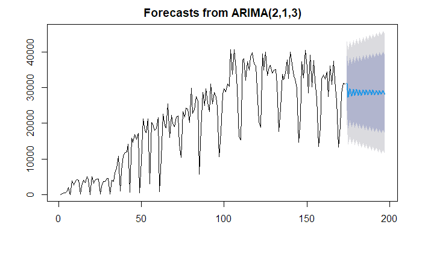

```r
#jurimetrics::fits(ts_ts(cymt_top5_agg), train = 0.9, steps = 4)
#Não sei pq o fits não funciona se consigo executar as avaliações separadamente -> mse.pred resulta em NA para todos então a variável bestModel fica sem atribuição

i <- ceiling(0.8*length(ts_cymt_top5_agg))

#Autoarima
fit.aa <- forecast::auto.arima(ts_cymt_top5_agg[1:i], seasonal = TRUE, seasonal.test="seas", ic="aic", allowdrift=FALSE,stepwise = FALSE, nmodels=300)
fcast.aa <- forecast::forecast(fit.aa, h=24)
plot(fcast.aa)
```

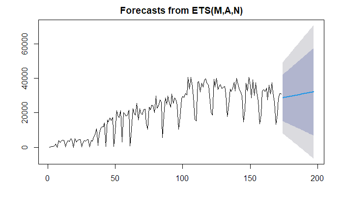

```r
#Exponential Smoothing
fit.ets <- forecast::ets(ts_cymt_top5_agg[1:i])
fcast.ets <- forecast::forecast(fit.ets, h=24)
plot(fcast.ets)
```

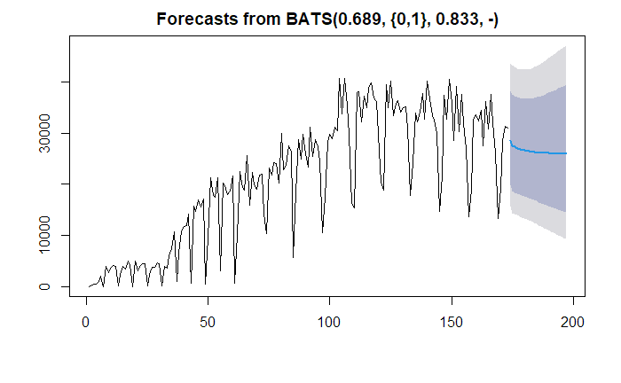

```r
# TBATS
# T for trigonometric regressors to model multiple-seasonalities
# B for Box-Cox transformations
# A for ARMA errors
# T for trend
# S for seasonality
fit.tb <- forecast::tbats(ts_cymt_top5_agg[1:i])
fcast.tb <- forecast::forecast(fit.tb, h=24)
plot(fcast.tb)
```

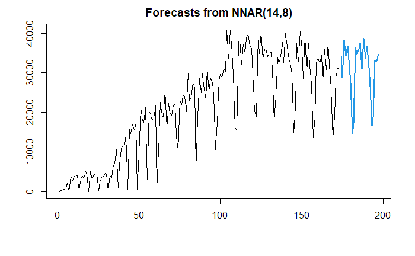

```r
#Neural Network Auto Regressive - NNETAR
set.seed(1);
fit.nn <- forecast::nnetar(ts_cymt_top5_agg[1:i])
fcast.nn <- forecast::forecast(fit.nn, h=24, PI = F)
plot(fcast.nn)
```

```r
adf.test(x=ts_cymt_top5_agg)
```

```
    Augmented Dickey-Fuller Test

data:  ts_cymt_top5_agg
Dickey-Fuller = -2.0394, Lag order = 5, p-value = 0.5595
alternative hypothesis: stationary
```

# Referências

```r
# Comentado por enquanto para economizar espaço
citation("jurimetrics")
```

```
  Zabala Filipe J. and Silveira Fabiano F. (2020). jurimetrics: General Purpose Tools for Jurimetrics. R package version 0.0.4.
  https://github.com/filipezabala/jurimetrics

A BibTeX entry for LaTeX users is

  @Manual{,
    title = {jurimetrics: General Purpose Tools for Jurimetrics},
    author = {Zabala {Filipe J.} and Silveira {Fabiano F.}},
    year = {2020},
    note = {R package version 0.0.4},
    url = {https://github.com/filipezabala/jurimetrics},
  }
```

```r
citation("dplyr")
```

```
  Hadley Wickham, Romain François, Lionel Henry and Kirill Müller (2020). dplyr: A Grammar of Data Manipulation. R package version 1.0.1.
  https://CRAN.R-project.org/package=dplyr

A BibTeX entry for LaTeX users is

  @Manual{,
    title = {dplyr: A Grammar of Data Manipulation},
    author = {Hadley Wickham and Romain François and Lionel Henry and Kirill Müller},
    year = {2020},
    note = {R package version 1.0.1},
    url = {https://CRAN.R-project.org/package=dplyr},
  }
```

```r
citation("tidyr")
```

```
  Hadley Wickham and Lionel Henry (2020). tidyr: Tidy Messy Data. R package version 1.1.1. https://CRAN.R-project.org/package=tidyr

A BibTeX entry for LaTeX users is

  @Manual{,
    title = {tidyr: Tidy Messy Data},
    author = {Hadley Wickham and Lionel Henry},
    year = {2020},
    note = {R package version 1.1.1},
    url = {https://CRAN.R-project.org/package=tidyr},
  }
```

```r
citation("conflicted")
```

```
  Hadley Wickham (2019). conflicted: An Alternative Conflict Resolution Strategy. R package version 1.0.4. https://CRAN.R-project.org/package=conflicted

A BibTeX entry for LaTeX users is

  @Manual{,
    title = {conflicted: An Alternative Conflict Resolution Strategy},
    author = {Hadley Wickham},
    year = {2019},
    note = {R package version 1.0.4},
    url = {https://CRAN.R-project.org/package=conflicted},
  }
```

```r
citation("foreach")
```

```
  Microsoft and Steve Weston (2020). foreach: Provides Foreach Looping Construct. R package version 1.5.0. https://CRAN.R-project.org/package=foreach

A BibTeX entry for LaTeX users is

  @Manual{,
    title = {foreach: Provides Foreach Looping Construct},
    author = {{Microsoft} and Steve Weston},
    year = {2020},
    note = {R package version 1.5.0},
    url = {https://CRAN.R-project.org/package=foreach},
  }
```

```r
citation("rlang")
```

```
  Lionel Henry and Hadley Wickham (2020). rlang: Functions for Base Types and Core R and 'Tidyverse' Features. R package version 0.4.7.
  https://CRAN.R-project.org/package=rlang

A BibTeX entry for LaTeX users is

  @Manual{,
    title = {rlang: Functions for Base Types and Core R and 'Tidyverse' Features},
    author = {Lionel Henry and Hadley Wickham},
    year = {2020},
    note = {R package version 0.4.7},
    url = {https://CRAN.R-project.org/package=rlang},
  }
```

```r
citation("rlist")
```

```
  Kun Ren (2016). rlist: A Toolbox for Non-Tabular Data Manipulation. R package version 0.4.6.1. https://CRAN.R-project.org/package=rlist

A BibTeX entry for LaTeX users is

  @Manual{,
    title = {rlist: A Toolbox for Non-Tabular Data Manipulation},
    author = {Kun Ren},
    year = {2016},
    note = {R package version 0.4.6.1},
    url = {https://CRAN.R-project.org/package=rlist},
  }

ATTENTION: This citation information has been auto-generated from the package DESCRIPTION file and may need manual editing, see ‘help("citation")’.
```

```r
citation("Metrics")
```

```
  Ben Hamner and Michael Frasco (2018). Metrics: Evaluation Metrics for Machine Learning. R package version 0.1.4. https://CRAN.R-project.org/package=Metrics

A BibTeX entry for LaTeX users is

  @Manual{,
    title = {Metrics: Evaluation Metrics for Machine Learning},
    author = {Ben Hamner and Michael Frasco},
    year = {2018},
    note = {R package version 0.1.4},
    url = {https://CRAN.R-project.org/package=Metrics},
  }
```

```r
citation("RQuantLib")
```

```
  Dirk Eddelbuettel, Khanh Nguyen and Terry Leitch (2020). RQuantLib: R Interface to the 'QuantLib' Library. R package version 0.4.12.
  https://CRAN.R-project.org/package=RQuantLib

A BibTeX entry for LaTeX users is

  @Manual{,
    title = {RQuantLib: R Interface to the 'QuantLib' Library},
    author = {Dirk Eddelbuettel and Khanh Nguyen and Terry Leitch},
    year = {2020},
    note = {R package version 0.4.12},
    url = {https://CRAN.R-project.org/package=RQuantLib},
  }

ATTENTION: This citation information has been auto-generated from the package DESCRIPTION file and may need manual editing, see ‘help("citation")’.
```

```r
citation("lubridate")
```

```
  Garrett Grolemund, Hadley Wickham (2011). Dates and Times Made Easy with lubridate. Journal of Statistical Software, 40(3), 1-25. URL
  http://www.jstatsoft.org/v40/i03/.

A BibTeX entry for LaTeX users is

  @Article{,
    title = {Dates and Times Made Easy with {lubridate}},
    author = {Garrett Grolemund and Hadley Wickham},
    journal = {Journal of Statistical Software},
    year = {2011},
    volume = {40},
    number = {3},
    pages = {1--25},
    url = {http://www.jstatsoft.org/v40/i03/},
  }
```

```r
citation("qcc")
```

```
  Scrucca, L. (2004). qcc: an R package for quality control charting and statistical process control. R News 4/1, 11-17.

A BibTeX entry for LaTeX users is

  @Article{,
    title = {qcc: an R package for quality control charting and statistical process control},
    author = {Luca Scrucca},
    journal = {R News},
    year = {2004},
    pages = {11--17},
    volume = {4/1},
    url = {https://cran.r-project.org/doc/Rnews/},
  }
```

```r
citation("xts")
```

```
  Jeffrey A. Ryan and Joshua M. Ulrich (2020). xts: eXtensible Time Series. R package version 0.12-0. https://CRAN.R-project.org/package=xts

A BibTeX entry for LaTeX users is

  @Manual{,
    title = {xts: eXtensible Time Series},
    author = {Jeffrey A. Ryan and Joshua M. Ulrich},
    year = {2020},
    note = {R package version 0.12-0},
    url = {https://CRAN.R-project.org/package=xts},
  }
```

```r
citation("timetk")
```

```
  Matt Dancho and Davis Vaughan (2020). timetk: A Tool Kit for Working with Time Series in R. R package version 2.2.0. https://CRAN.R-project.org/package=timetk

A BibTeX entry for LaTeX users is

  @Manual{,
    title = {timetk: A Tool Kit for Working with Time Series in R},
    author = {Matt Dancho and Davis Vaughan},
    year = {2020},
    note = {R package version 2.2.0},
    url = {https://CRAN.R-project.org/package=timetk},
  }
```

```r
citation("mFilter")
```

```
  Mehmet Balcilar (2019). mFilter: Miscellaneous Time Series Filters. R package version 0.1-5. https://CRAN.R-project.org/package=mFilter

A BibTeX entry for LaTeX users is

  @Manual{,
    title = {mFilter: Miscellaneous Time Series Filters},
    author = {Mehmet Balcilar},
    year = {2019},
    note = {R package version 0.1-5},
    url = {https://CRAN.R-project.org/package=mFilter},
  }

ATTENTION: This citation information has been auto-generated from the package DESCRIPTION file and may need manual editing, see ‘help("citation")’.
```

```r
citation("tsbox")
```

```
  Christoph Sax (2020). tsbox: Class-Agnostic Time Series. R package version 0.2.1. https://CRAN.R-project.org/package=tsbox

A BibTeX entry for LaTeX users is

  @Manual{,
    title = {tsbox: Class-Agnostic Time Series},
    author = {Christoph Sax},
    year = {2020},
    note = {R package version 0.2.1},
    url = {https://CRAN.R-project.org/package=tsbox},
  }
```

```r
citation("imputeTS")
```

```
Moritz S, Bartz-Beielstein T (2017). “imputeTS: Time Series Missing Value Imputation in R.” _The R Journal_, *9*(1), 207-218. doi: 10.32614/RJ-2017-009 (URL:
https://doi.org/10.32614/RJ-2017-009).

A BibTeX entry for LaTeX users is

  @Article{,
    title = {{imputeTS: Time Series Missing Value Imputation in R}},
    author = {Steffen Moritz and Thomas Bartz-Beielstein},
    journal = {{The R Journal}},
    volume = {9},
    number = {1},
    pages = {207--218},
    year = {2017},
    doi = {10.32614/RJ-2017-009},
  }
```

```r
citation("tseries")
```

```
  Adrian Trapletti and Kurt Hornik (2019). tseries: Time Series Analysis and Computational Finance. R package version 0.10-47.

A BibTeX entry for LaTeX users is

  @Manual{,
    title = {tseries: Time Series Analysis and Computational Finance},
    author = {Adrian Trapletti and Kurt Hornik},
    year = {2019},
    note = {R package version 0.10-47.},
    url = {https://CRAN.R-project.org/package=tseries},
  }
```

```r
citation("vars")
```

```
  Bernhard Pfaff (2008). VAR, SVAR and SVEC Models: Implementation Within R Package vars. Journal of Statistical Software 27(4). URL http://www.jstatsoft.org/v27/i04/.

  Pfaff, B. (2008) Analysis of Integrated and Cointegrated Time Series with R. Second Edition. Springer, New York. ISBN 0-387-27960-1

For BibTex versions of citations use: toBibtex(citation('vars'))
To see these entries in BibTeX format, use 'print(<citation>, bibtex=TRUE)', 'toBibtex(.)', or set 'options(citation.bibtex.max=999)'.
```

```r
citation("MTS")
```

```
  Ruey S. Tsay and David Wood (2018). MTS: All-Purpose Toolkit for Analyzing Multivariate Time Series (MTS) and Estimating Multivariate Volatility Models. R package
  version 1.0. https://CRAN.R-project.org/package=MTS

A BibTeX entry for LaTeX users is

  @Manual{,
    title = {MTS: All-Purpose Toolkit for Analyzing Multivariate Time Series (MTS)
and Estimating Multivariate Volatility Models},
    author = {Ruey S. Tsay and David Wood},
    year = {2018},
    note = {R package version 1.0},
    url = {https://CRAN.R-project.org/package=MTS},
  }

ATTENTION: This citation information has been auto-generated from the package DESCRIPTION file and may need manual editing, see ‘help("citation")’.
```

VAR - BIC - AIC - Lags significativos lags,season 1,1 3,6

- Lags handpicked 1,3,6,12
- Interpretar os coeficientes significativos (estimates…)
- Fazer a predição (forecast)
- Comparar projeção com o último ano
- Explicar o modelo com as projeções anteriores

Estimate -> Diferença em relação 0 Std. Error -> Erro padrão t value -> Estimate/Std. Error Pr(>|t|) -> Percentual de t ao infinito